# Impact of Cognitive Control on Theory of Mind in Early Adolescent Antisocial Phenotypes

Drew E. Winters, PhD.

30 October, 2024

- Initial Info
  - Preregistered collection and analysis: https://doi.org/10.17605/OSF.IO/BHWEU
  - Publication this data replicates: https://doi.org/10.1080/02699931.2023.2195154

# 1 Setup

## 1.1 Packages Used

```r
  ## confirmatory factor analysis
library(lavaan)
  ## Power analysis
library(simr)

  ## model testing for mixed effects
library(lmerTest) # mixed effects modeling

  ## for testing zero inflated models
library(pscl)

  ## for model diagnostics
library(performance)
library(see)

  # for plotting
library(dplyr)
library(magrittr)
library(forcats)
library(ggplot2)
# library(ggstatsplot) # stat plot - call later to suppress weird cite message
# library(corrplott) # correlation plots - call later without loading here
# library(crayon) # colored output - call later without loading here

  # for descriptive statistics
library(psych)
```

## 1.2 Data Loading

```r
dat <- read.csv(file.path(dataframe_final_subs))
```

## 1.3 Functions Used

### 1.3.1 Checking Data Assumptions

```r
  # checking for model singularity (to be used in assumptions function)
singularity_chk <- function(x){
  if (check_singularity(x)==FALSE){
    return(crayon::green("OK: Model Not Singular"))
  }
  else if (check_singularity(x)==TRUE){
    return(crayon::red("Warning: Model Singular"))
  }
}

  # checking covergence of the model (to be used in assumptions function)
convergence_chk <- function(x){
  if (check_convergence(x)[1]==TRUE){
    return(crayon::green("OK: Model Converged"))
  }
  else if (check_convergence(x)[1]==FALSE){
    return(crayon::red("Warning: Model did not converge"))
  }
}


  # checking multicollinerity of the model (to be use in assumptions function)
collinearity_chk <- function(x){
  mcoll<-any(car::vif(x)[1:11] >3)
  if (mcoll == "FALSE") {
    return(crayon::green(("OK: No Multicollinearity (All IVs VIF < 3)")))
  }
  else if (mcoll == "TRUE") {
    return(crayon::red(("WARNING: Multicolinearity exists (Some IVs VIF > 3)")))
  }
}

  # Checking if IVs are exogenous (not endogenous)
    ## see: https://doi.org/10.1177/1094428119877457
endogenity_chk <- function(x, data, ch_lag=16){
  library(plm)
  char_all<-Reduce(paste,deparse(x@call$formula))
  char_formula<-(substr(char_all,1,(nchar(char_all)-ch_lag)))
  re<-plm(
    formula(char_formula),
    data=data,
    model="random"
  )
  fe<-lm(formula(char_formula), data=data)
  ex_results<-phtest(
    re,
    fe
  )
  if (ex_results$p.value > 0.05){
    return(crayon::green(("OK: IVs are exogenous (p > 0.05)")))
  } else if (ex_results$p.value < 0.05) {
    return(crayon::red(("Warning: IVs are endogenous (p < 0.05)")))
  }
}

  # checking if random effects models the data better than fixed effects alone
re_necessary_chk <- function(xx, data, ch_lag=16){
  char_all<-Reduce(paste,deparse(xx@call$formula))
  char_formula<-(substr(char_all,1,(nchar(char_all)-ch_lag)))
  fix <- lm(formula(char_formula), data=data)
  re <- lmer(xx,data=data, REML = FALSE, control = control)
  re_nec_results <- anova(re, fix)
  if (re_nec_results$`Pr(>Chisq)`[2] < 0.06){
    return(crayon::green(("OK: Random effects indicated")))
  } else if (re_nec_results$`Pr(>Chisq)`[2] > 0.06) {
    return(crayon::red(("Warning: Random effects not necessary")))
  }
}


  # checking all data assumptions
assumptions <- function(model, data, ch_lag=16) {
  library(performance)
  library(see)
  set.seed(734)
  model_re <- lme4::lmer(model, data=data)
  singularity <- singularity_chk(model_re)
  convergence <- convergence_chk(model_re)
  heteroscedasticity<-check_heteroscedasticity(model_re)
  autocorrelation<-check_autocorrelation(model_re)
  normality <- check_residuals(model_re)
  collinearity <- (collinearity_chk(model_re))
  outliers <- check_outliers(model_re)
  endogenity <- endogenity_chk(model_re, data= data, ch_lag)
  re_nec <- re_necessary_chk(model_re, data= data, ch_lag)
  cat(" Convergence:      ")
  cat(convergence)
  cat("\n Singularity:      ")
  cat(singularity)
  cat("\n Heteroscedacity:  ")
  print(heteroscedasticity)
  cat(" Autocorrelation:  ")
  print(autocorrelation)
  cat("\n Residual dist:    ")
  print(normality)
  cat(" Multicollinerity: ")
  cat(collinearity)
  cat("\n Endogenity:       ")
  cat(endogenity)
  cat("\n Random effects:   ")
  cat(re_nec)
  cat("\n Outliers:         ")
  print(outliers)
}
```

### 1.3.2 Bootstrapping and Reporting

```r
  # function for reporting bootstrapped corrected values
mix_boot_report <- function(model, data=dat_long) {
  # functions
    ## 1) extract parameters for bootstrapping
  mySumm2 <- function(.) {
    c(
      beta=fixef(.),                                # fixed effects
      tval=as.data.frame(
        summary(.)$coefficients
        )$`t value`,                                # t values (p correction)
      sigma_resid_sd=sigma(.),                      # random residual sd
      signa_resid_var=var(resid(.)),                # random residual variance
      sig01_random_eff_sd=sqrt(unlist(VarCorr(.))), # random effect sd
      sig01_random_eff_var=unlist(VarCorr(.))       # random effect variance
    )
  }
    ## 2) Satterwaite correction for bootstrapped corrected p values
  sat_p_val <- function(dof_mod, boot_df, tind) {
    p_vals <- list()
    dof <- as.data.frame(summary(dof_mod)$coefficients)$df
    dof_ind <- 0
    for (ii in tind) {
      dof_ind <- (dof_ind + 1)
      p_value <- 2 * (
        1 - pt(abs(as.data.frame(boot_df$stats$rep.mean)[ii,]), dof[dof_ind])
        )
      p_vals <- append(p_vals,p_value)
    }
    return(unlist(p_vals))
  }

  # bootstrapping
  set.seed(1985) # setting seed
  boot.ci <- lmeresampler::bootstrap(
    lme4::lmer(
      model,
      data = data),
    .f= mySumm2,
    B = 10000,
    type = "reb",
    reb_type = 1)
    # we resample 10,000 bootstraps for proper estimation fo CIs
    # we use random effect block bootstrapping
      # a non-parametric bootstrap resampling (1) residuals (2) within clusters
        ## (1) Residual resampling does not impose normality of residuals
          #> addresses issues with the model if residuals are non-normal
          #> this makes residual bootstrapping a more reliable than parametric
          #> see this link: https://www.jstor.org/stable/43304840
          #> https://www.stat.cmu.edu/~cshalizi/uADA/13/lectures/which-bootstrap-when.pdf
        ## (2) looseness assumptions on the residual covariance structure
          #> i.e., this approach doesn't require a specific covariance structure
          #> this is important because:
            #> subjects in the non-test condition are expected to not change
            #> loosening this assumption improves estimation for this task
      # this method is robust to failure of dependence assumptions in MLM
        ## see: https://www.jstor.org/stable/43304840

  # identifying indices for metrics extracted
  beta_ind = which(
    startsWith(as.data.frame(confint(boot.ci, type = "norm"))$term, "beta"))
  tval_ind = which(
    startsWith(as.data.frame(confint(boot.ci, type = "norm"))$term, "tval"))
  resid_sd_ind = which(
    startsWith(as.data.frame(
      confint(boot.ci, type = "norm"))$term, "sigma_resid_sd"))
  rand_eff_sd_ind = which(
    startsWith(as.data.frame(
      confint(boot.ci, type = "norm"))$term, "signa_resid_var"))
  resid_var_ind = which(
    startsWith(as.data.frame(
      confint(boot.ci, type = "norm"))$term, "sig01_random_eff_sd"))
  rand_eff_var_ind = which(
    startsWith(as.data.frame(
      confint(boot.ci, type = "norm"))$term, "sig01_random_eff_var"))

  # extracting corrected betas
  total_results <- as.data.frame(
    boot.ci[5])[beta_ind , c("stats.term", "stats.rep.mean", "stats.se")]
  colnames(total_results) <- c("term", "beta.boot", "se.boot")

  # extracting corrected t values
  t_df <- as.data.frame(
    as.data.frame(boot.ci[5])[tval_ind , c("stats.rep.mean")])
  colnames(t_df) <- "t.boot"
  total_results <- cbind(total_results, t_df)

  # extracting corrected p values
  p_df <- as.data.frame(sat_p_val(model,boot.ci,tval_ind))
  colnames(p_df) <- "p.satw_boot"
  total_results <- cbind(total_results, p_df)

  # extracting corrected random effects
    ## var
  rand_var <- as.data.frame(
    as.data.frame(boot.ci[5])[rand_eff_var_ind , c("stats.rep.mean")])
  rand_var <- cbind("rand_var",rand_var)
  rand_var_se <- as.data.frame(boot.ci[5])[rand_eff_var_ind , c("stats.se")]
  rand_var <- cbind(rand_var,t(as.data.frame(c(rand_var_se,NA,NA))))
  colnames(rand_var) <- colnames(total_results)
  rownames(rand_var) <- 21
  total_results <- rbind(total_results, rand_var)
    ## sd
  rand_sd <- as.data.frame(
    as.data.frame(boot.ci[5])[rand_eff_sd_ind , c("stats.rep.mean")])
  rand_sd <- cbind("rand_sd",rand_sd)
  rand_sd_se <- as.data.frame(boot.ci[5])[rand_eff_sd_ind , c("stats.se")]
  rand_sd <- cbind(rand_sd,t(as.data.frame(c(rand_sd_se,NA,NA))))
  colnames(rand_sd) <- colnames(total_results)
  rownames(rand_sd) <- 22
  total_results <- rbind(total_results, rand_sd)

  # extracting corrected random effect residuals
    ## var
  resid_var <- as.data.frame(
    as.data.frame(boot.ci[5])[resid_var_ind , c("stats.rep.mean")])
  resid_var <- cbind("resid_var",resid_var)
  resid_var_se <- as.data.frame(boot.ci[5])[resid_var_ind , c("stats.se")]
  resid_var <- cbind(resid_var,t(as.data.frame(c(resid_var_se,NA,NA))))
  colnames(resid_var) <- colnames(total_results)
  rownames(resid_var) <- 23
  total_results <- rbind(total_results, resid_var)
    ## sd
  resid_sd <- as.data.frame(
    as.data.frame(boot.ci[5])[resid_sd_ind , c("stats.rep.mean")])
  resid_sd <- cbind("resid_sd",resid_sd)
  resid_sd_se <- as.data.frame(boot.ci[5])[resid_sd_ind , c("stats.se")]
  resid_sd <- cbind(resid_sd,t(as.data.frame(c(resid_sd_se,NA,NA))))
  colnames(resid_sd) <- colnames(total_results)
  rownames(resid_sd) <- 24
  total_results <- rbind(total_results, resid_sd)

  # extracting bootstrapped confidence intervals (CI)
    ## for betas we use the percentile confidence interval
      ### this method uses percentiles of the bootstrap sampling distribution
          # and does not impose assumptions of distribution normality
      ### we use this because the non-normality of interactions and standard
          # error equation is not straight forward for interaction terms
          # see: https://www.e-education.psu.edu/eme210/node/608
    ## for random effects we use normal confidence intervals
      ### this method uses the standard error of the sampling distribution and
          # imposes assumptions of normality.
      ### but why do this?
        #### mixed effects already imposes assumptions of normality on residual
            # distribution in its estimation
        #### The random effect residual distribution is theoretical as a source
            # of unknown variance thus is should be normal
        #### bootstrapping should make residual distribution normal over 10,000
            # resamples (if not already normal)
        #### it is important to note that this will have no bearing on the
            # inferences made for the betas predicting the outcome of interest
        #### practically this won't make a substantive difference but
            # theoretically this seems most sound
    ## why use one CI method for on and another method for another?
      ### to summarize the case for why we would use different CI methods:
        #### non-normality of betas need to be considered
        #### normal distribution of random effect residuals needs considered
  beta.ci <- as.data.frame(
    confint(boot.ci, type = "perc"))[beta_ind , c("lower", "upper")]
  rand_eff_sd.ci <- as.data.frame(
    confint(boot.ci, type = "norm"))[rand_eff_sd_ind , c("lower", "upper")]
  resid_sd.ci <- as.data.frame(
    confint(boot.ci, type = "norm"))[resid_sd_ind , c("lower", "upper")]
  rand_eff_var.ci <- as.data.frame(
    confint(boot.ci, type = "norm"))[rand_eff_var_ind , c("lower", "upper")]
  resid_var.ci <- as.data.frame(
    confint(boot.ci, type = "norm"))[resid_var_ind , c("lower", "upper")]
  beta.boot_ci <- rbind(
    beta.ci,rbind(rand_eff_sd.ci,resid_sd.ci))
  beta.boot_ci <- rbind(
    beta.boot_ci,rbind(rand_eff_var.ci,resid_var.ci))
  colnames(beta.boot_ci) <- c("ci.boot_low", "ci.boot_hi")
  total_results <- cbind(total_results, beta.boot_ci)

  # extracting r2 values
  r2_vals <- performance(model)
  r2s <- rbind(c(as.data.frame(r2_vals)$R2_marginal,NA,NA,NA,NA,NA),
               c(as.data.frame(r2_vals)$R2_conditional,NA,NA,NA,NA,NA))
  r2s <- cbind(as.data.frame(c("R2.marginal","R2.conditional")),r2s)
  colnames(r2s) <- colnames(total_results)
  rownames(r2s) <- c(25, 26)
  total_results <- rbind(total_results, r2s)

  # removing "beta." prefix to term names
  total_results$term <- stringr::str_replace_all(
    total_results$term, "beta.", "")

  # removing term column and making row name
  rownames(total_results) <- total_results$term
  total_results <- total_results[,2:7]

  # returning dataframe at 3 digits
  return(format(total_results ,digits = 3))
}
```

## 1.4 Structuring Data

- Repeated measures (Long) Data

```r
  # stacking variables
ids <- rep(1:length(dat$tom_s_acc_total_sum),2)
time<- c(rep(0, length(dat$tom_s_acc_total_sum)),
         rep(1, length(dat$tom_s_acc_total_sum)))
cu_long<- c(dat$cu_total_mean,dat$cu_total_mean)
sdq_cd_long<- c((dat$sdq_cd/5),(dat$sdq_cd/5)) # for a mean score
tom_acc_total<- c(dat$tom_s_acc_total_sum,dat$tom_d_acc_total_sum)
tom_acc_at<- c(dat$tom_s_acc_at_sum,dat$tom_d_acc_at_sum)
tom_acc_ct<- c(dat$tom_s_acc_ct_sum,dat$tom_d_acc_ct_sum)
tom_acc_pc<- c(dat$tom_s_acc_pc_sum,dat$tom_d_acc_pc_sum)
tom_rt_total<- c(dat$tom_s_rt_total_mean,dat$tom_d_rt_total_mean)
tom_rt_at<- c(dat$tom_s_rt_at_mean,dat$tom_d_rt_at_mean)
tom_rt_ct<- c(dat$tom_s_rt_ct_mean,dat$tom_d_rt_ct_mean)
tom_rt_pc<- c(dat$tom_s_rt_pc_mean,dat$tom_d_rt_pc_mean)
sex_male_long<- c(dat$sex_male , dat$sex_male )
race_white_long<- c(dat$race_white , dat$race_white )
iq_long<- c(dat$iq , dat$iq )
careless_long<- c(dat$careless , dat$careless )
sdq_hyperactivity_long<- c((dat$sdq_hyperactivity/5),
                           (dat$sdq_hyperactivity/5)) # for a mean score
sdq_internalizing_long<- c((dat$sdq_internalizing/10),
                           (dat$sdq_internalizing/10)) # for a mean score
order_var_long<- c(dat$order_var , dat$order_var )
group_di_long<- c(dat$group_di , dat$group_di )

  # placing in long format dataframe
dat_long = data.frame(
  id = ids,
  time = time,
  cu = cu_long,
  sdq_cd = sdq_cd_long,
  tom_acc_total = tom_acc_total,
  tom_acc_at = tom_acc_at,
  tom_acc_ct = tom_acc_ct,
  tom_acc_pc = tom_acc_pc,
  tom_rt_total = tom_rt_total,
  tom_rt_at = tom_rt_at,
  tom_rt_ct = tom_rt_ct,
  tom_rt_pc = tom_rt_pc,
  sex_male = sex_male_long,
  race_white = race_white_long,
  iq = iq_long,
  careless = careless_long,
  sdq_hyperactivity = sdq_hyperactivity_long,
  sdq_internalizing = sdq_internalizing_long,
  order_var = order_var_long,
  group_di = group_di_long
  )
```

### 1.4.1 Interaction terms

- Derived using Centered Residual Interaction Terms
- see:
  - https://doi.org/10.1177/0013164412445473
  - https://doi.org/10.1207/s15328007sem1304_1
- Also this approach keeps us from violating regression/mixed models assumptions
  - for assumptions see: https://doi.org/10.1177/1094428119877457

#### 1.4.1.1 Repeated Measure Interactions

- Repeated Measures (Long Form) Interactions

```r
  # group x time
dat_long$int_gptime <- resid(
  lm(I(group_di*time) ~ group_di+time, data=dat_long)
  )

  # cu x cd
dat_long$int_cdcu <- resid(
  lm(I(sdq_cd*cu) ~ sdq_cd+cu, data=dat_long)
  )
dat_long$int_cdcugp <- resid(
  lm(I(sdq_cd*cu*group_di) ~ sdq_cd+cu+group_di, data=dat_long)
  )
dat_long$int_cdcugptime <- resid(
  lm(I(sdq_cd*cu*group_di*time) ~ sdq_cd+cu+group_di+time, data=dat_long)
  )
dat_long$int_cdcutime <- resid(
  lm(I(sdq_cd*cu*time) ~ sdq_cd+cu+time, data=dat_long)
  )

  # cu
dat_long$int_cugp <- resid(
  lm(I(cu*group_di) ~ cu+group_di, data=dat_long)
  )
dat_long$int_cutime <- resid(
  lm(I(cu*time) ~ cu+time, data=dat_long)
  )
dat_long$int_cugptime <- resid(
  lm(I(cu*group_di*time) ~ cu+group_di+time, data=dat_long)
  )

  # cd
dat_long$int_cdgp <- resid(
  lm(I(sdq_cd*group_di) ~ sdq_cd+group_di, data=dat_long)
  )
dat_long$int_cdtime <- resid(
  lm(I(sdq_cd*time) ~ sdq_cd+time, data=dat_long)
  )
dat_long$int_cdgptime <- resid(
  lm(I(sdq_cd*group_di*time) ~ sdq_cd+group_di+time, data=dat_long)
  )
```

#### 1.4.1.2 Single Measure Interactions

- Single Measure (Wide) Interactions

```r
dat$int_cutest <- resid(
  lm(I(dat$group_di * dat$cu_total_mean) ~ dat$group_di + dat$cu_total_mean)
  )
dat$int_cdtest <- resid(
  lm(I(dat$group_di * dat$sdq_cd) ~ dat$group_di + dat$sdq_cd)
  )
dat$int_cucd <- resid(
  lm(I(dat$sdq_cd * dat$cu_total_mean) ~ dat$sdq_cd + dat$cu_total_mean)
  )
dat$int_cucdtest <- resid(
  lm(
    I(dat$sdq_cd * dat$cu_total_mean * dat$group_di) ~
      dat$sdq_cd + dat$cu_total_mean + dat$group_di)
  )
```

# 2 Sample Descriptives

## 2.1 Continuous Descriptive Stats

```r
  # continuous descriptive stats
(cont_des<-as.data.frame(
  describe(
    dat[
      c(
        "iq",
        "age",
        "sdq_cd",
        "cu_total_sum",
        "sdq_hyperactivity",
        "sdq_internalizing",
        "careless"
        )]))[,
             c("mean","sd","min","max","range")
             ])
```

|  | mean | sd | min | max | range |
| --- | --- | --- | --- | --- | --- |
| iq | 94.8459739 | 17.0265916 | 70 | 167.8277 | 97.8277 |
| age | 13.0352941 | 0.8373294 | 12 | 14.0000 | 2.0000 |
| sdq_cd | 1.6117647 | 1.6979968 | 0 | 6.0000 | 6.0000 |
| cu_total_sum | 16.1882353 | 6.9427834 | 0 | 30.0000 | 30.0000 |
| sdq_hyperactivity | 4.1411765 | 2.8666927 | 0 | 10.0000 | 10.0000 |
| sdq_internalizing | 5.3294118 | 3.7013133 | 0 | 16.0000 | 16.0000 |
| careless | 0.1764706 | 0.3834825 | 0 | 1.0000 | 1.0000 |

```r
write.csv(
  cont_des,
  paste0(base,"\\demographics_continuous.csv"),
  row.names=TRUE
)
```

```r
desc_gp <- dat[
      c(
        "iq",
        "age",
        "sdq_cd",
        "cu_total_sum",
        "sdq_hyperactivity",
        "sdq_internalizing",
        "careless",
        "group_di"
        )]
  # continuous descriptive stats control group
cont_des_gp0<-as.data.frame(
  describeBy(
    desc_gp, group = "group_di")$'0')[1:7,
             c("mean","sd","min","max","range")
             ]
ctrl_row <- t(as.data.frame(c("*CONTROL GROUP*", "-", "-", "-", "-")))
rownames(ctrl_row) <- "group compare"
colnames(ctrl_row) <- colnames(cont_des_gp0)

cont_des_gp0 <- rbind(ctrl_row, cont_des_gp0)

  # continuous descriptive stats test group
cont_des_gp1<-as.data.frame(
  describeBy(
    desc_gp, group = "group_di")$'1')[1:7,
             c("mean","sd","min","max","range")
             ]
test_row <- t(as.data.frame(c("*TEST GROUP*", "-", "-", "-", "-")))
rownames(test_row) <- "group compare"
colnames(test_row) <- colnames(cont_des_gp1)

cont_des_gp1 <- rbind(test_row, cont_des_gp1)

  # t tests
models_t <- function(x) {
  model1 <- t.test(x ~ group_di,
                 data = desc_gp)$p.value
  return(model1)
}

t_out <- as.data.frame(apply(desc_gp[,1:7],2, models_t))
colnames(t_out) <- "t.test_p"
tt <- as.data.frame("-")
rownames(tt) <- "group compare"
colnames(tt) <- "t.test_p"
t_out <- rbind(tt, t_out)

cont_des_gp <- cbind(cont_des_gp0, cont_des_gp1)

(cont_des_gp <- cbind(cont_des_gp, t_out))
```

|  | mean | sd | min | max | range | mean | sd | min | max | range | t.test_p |
| --- | --- | --- | --- | --- | --- | --- | --- | --- | --- | --- | --- |
| group compare | *CONTROL GROUP* | - | - | - | - | *TEST GROUP* | - | - | - | - | - |
| iq | 92.1287932653061 | 14.6343317365685 | 71.40308 | 131.2185 | 59.81542 | 98.5443586111111 | 19.4333798094933 | 70 | 167.8277 | 97.8277 | 0.101088385264747 |
| age | 13.0204081632653 | 0.828899770739486 | 12 | 14 | 2 | 13.0555555555556 | 0.860047986848722 | 12 | 14 | 2 | 0.850579953418234 |
| sdq_cd | 1.55102040816327 | 1.72072204430044 | 0 | 6 | 6 | 1.69444444444444 | 1.68725380332225 | 0 | 5 | 5 | 0.702047533700349 |
| cu_total_sum | 16.9387755102041 | 7.49279699462898 | 0 | 30 | 30 | 15.1666666666667 | 6.06865482859022 | 1 | 27 | 26 | 0.232305943559163 |
| sdq_hyperactivity | 3.87755102040816 | 2.74342132094538 | 0 | 9 | 9 | 4.5 | 3.02843665468317 | 0 | 10 | 10 | 0.333334395282206 |
| sdq_internalizing | 4.6530612244898 | 3.43117460699299 | 0 | 13 | 13 | 6.25 | 3.90146492633582 | 0 | 16 | 16 | 0.0538625214545338 |
| careless | 0.163265306122449 | 0.373437789079955 | 0 | 1 | 1 | 0.194444444444444 | 0.401386485959743 | 0 | 1 | 1 | 0.716628436015234 |

```r
write.csv(
  cont_des_gp,
  paste0(base,"\\demographics_continuous_group.csv"),
  row.names=TRUE
)
```

## 2.2 Dichotomous Descriptive Stats

### 2.2.1 Sex

```r
sex_des <- as.data.frame(rbind(as.character(table(dat$sex_male)),round((table(dat$sex_male) / sum(table(dat$sex_male))*100),3) ))
colnames(sex_des) <- c("female", "male")
rownames(sex_des) <- c("#", "%")
sex_des
```

|  | female | male |
| --- | --- | --- |
| # | 40 | 45 |
| % | 47.059 | 52.941 |

```r
write.csv(
  sex_des,
  paste0(base,"\\demographics_sex.csv"),
  row.names=TRUE
)
```

#### 2.2.1.1 Sex by group

```r
sex_gp <- data.frame(matrix(table(dat$sex_male, dat$group_di),nrow=2))
rownames(sex_gp) <- c("female", "male")
colnames(sex_gp) <- c("control", "test")

sex_gp$p <- c(chisq.test(sex_gp)$p.value, "-")

sex_gp
```

|  | control | test | p |
| --- | --- | --- | --- |
| female | 24 | 16 | 0.846157182792132 |
| male | 25 | 20 | - |

```r
write.csv(
  sex_gp,
  paste0(base,"\\demographics_sex_by_group.csv"),
  row.names=TRUE
)
```

### 2.2.2 Race

- race categories
  - 1= american Indian or native Alaskan
  - 2= Asian
  - 3= black
  - 4= Hispanic or Latino
  - 5= native Hawaiian or other pacific islander
  - 6= white
  - 7= mixed race

```r
race_des <- as.data.frame(rbind(as.character(table(dat$race)),round((table(dat$race) / sum(table(dat$race))*100),3) ))
colnames(race_des) <- c("am_ind", "asian", "black", "hisp", "white", "mixed")
rownames(race_des) <- c("#", "%")
race_des
```

|  | am_ind | asian | black | hisp | white | mixed |
| --- | --- | --- | --- | --- | --- | --- |
| # | 1 | 10 | 6 | 4 | 57 | 7 |
| % | 1.176 | 11.765 | 7.059 | 4.706 | 67.059 | 8.235 |

```r
write.csv(
  race_des,
  paste0(base,"\\demographics_race.csv"),
  row.names=TRUE
)
```

#### 2.2.2.1 White by group

```r
white_gp <- data.frame(matrix(table(dat$race_white, dat$group_di),nrow=2))
rownames(white_gp) <- c("non-white", "white")
colnames(white_gp) <- c("control", "test")

white_gp$p <- c(chisq.test(white_gp)$p.value, "-")

white_gp
```

|  | control | test | p |
| --- | --- | --- | --- |
| non-white | 15 | 13 | 0.764588345571154 |
| white | 34 | 23 | - |

```r
write.csv(
  white_gp,
  paste0(base,"\\demographics_white_by_group.csv"),
  row.names=TRUE
)
```

### 2.2.3 Phenotype Clinical

- SDQ cutoffs based on normative info:
- https://www.sdqinfo.org/norms/USNorm5.pdf
- https://doi.org/10.1186%2Fs13034-021-00437-8
  - conduct = 3 (90th percentile)
  - hyperactivity = 6 (90th percentile)
  - internalizing = 8 (90th percentile)

#### 2.2.3.1 N by cutoff

```r
# CU
cu_hi_des <- as.data.frame(rbind(as.character(table(dat$cu_high)),round((table(dat$cu_high) / sum(table(dat$cu_high))*100),2) ))
colnames(cu_hi_des) <- c("norm_cu", "high_cu")
rownames(cu_hi_des) <- c("#", "%")

# CD
clin_cd <- rep(0,length(dat$sdq_cd))
clin_cd[which(dat$sdq_cd > 3)] <- 1

cd_hi_des <- as.data.frame(rbind(as.character(table(clin_cd)),round((table(clin_cd) / sum(table(clin_cd))*100),2) ))
colnames(cd_hi_des) <- c("norm_CD", "high_CD")
rownames(cd_hi_des) <- c("#", "%")

# ADHD
clin_adhd <- rep(0,length(dat$sdq_hyperactivity))
clin_adhd[which(dat$sdq_hyperactivity > 6)] <- 1

adhd_hi_des <- as.data.frame(rbind(as.character(table(clin_adhd)),round((table(clin_adhd) / sum(table(clin_adhd))*100),2) ))
colnames(adhd_hi_des) <- c("norm_adhd", "high_adhd")
rownames(adhd_hi_des) <- c("#", "%")

# internalizing

clin_internalizing <- rep(0,length(dat$sdq_internalizing))
clin_internalizing[which(dat$sdq_internalizing > 8)] <- 1

internalizing_hi_des <- as.data.frame(rbind(as.character(table(clin_internalizing)),round((table(clin_internalizing) / sum(table(clin_internalizing))*100),2) ))
colnames(internalizing_hi_des) <- c("norm_internalizing", "high_internalizing")
rownames(internalizing_hi_des) <- c("#", "%")

clin_sx <- cbind(cu_hi_des, cd_hi_des)
clin_sx <- cbind(clin_sx, adhd_hi_des)
(clin_sx <- cbind(clin_sx, internalizing_hi_des))
```

|  | norm_cu | high_cu | norm_CD | high_CD | norm_adhd | high_adhd | norm_internalizing | high_internalizing |
| --- | --- | --- | --- | --- | --- | --- | --- | --- |
| # | 44 | 41 | 70 | 15 | 63 | 22 | 70 | 15 |
| % | 51.76 | 48.24 | 82.35 | 17.65 | 74.12 | 25.88 | 82.35 | 17.65 |

```r
write.csv(
  clin_sx,
  paste0(base,"\\demographics_clinical_sx.csv"),
  row.names=TRUE
)
```

#### 2.2.3.2 N by clinical CU

```r
  # divisors
div_cu_clin <- rep(
  rowSums(
    table(
      data.frame('cu' = dat$cu_high, 'cd' = clin_cd))
    ),
  2
  )

div_CD_clin <- c(
  rep(as.numeric(table(clin_cd)[1]),
      2),
  rep(as.numeric(table(clin_cd)[2]),
      2)
  )

div_ADHD_clin <- c(
  rep(as.numeric(table(clin_adhd)[1]),
      2
      ),
  rep(as.numeric(table(clin_adhd)[2]),
      2)
  )

div_internalizing_clin <- c(
  rep(as.numeric(table(clin_internalizing)[1]),
      2),
  rep(as.numeric(table(clin_internalizing)[2]),
      2)
  )

  # setting up DF
cu_sx <- data.frame(
  "CU_Clin" =
    as.data.frame(table(data.frame('cu' = dat$cu_high, 'cd' = clin_cd)))$cu,
  "CU_N-*-Clin.CU" =
    div_cu_clin
  )

  # CD
table_cd <- table(
  data.frame('cu' = dat$cu_high, 'cd' = clin_cd)
  )

cd_sx <- cbind(
  as.data.frame(table_cd),
  as.data.frame(
    round(
      table(
        data.frame('cu' = dat$cu_high, 'cd' = clin_cd)
        ) /
        div_cu_clin,
      2
      )
    )$Freq
  )

cd_sx <- cbind(
  cd_sx,
  as.data.frame(
    round(
      table(
        data.frame('cu' = dat$cu_high, 'cd' = clin_cd)
        ) /
        div_CD_clin,
      2)
    )$Freq
  )

colnames(cd_sx) <- c(
  "cu_clin",
  "CD_Clin",
  "CD_N-*-Clin.CU",
  "CD_%-*-N.CU",
  "CD_%-*-N.Clin.CD")

cu_sx <- cbind(cu_sx,cd_sx[,2:5])


table_adhd <- table(data.frame('cu' = dat$cu_high, 'adhd' = clin_adhd))
adhd_sx <-  cbind(
  as.data.frame(table_adhd),
  as.data.frame(
    round(
      table(
        data.frame('cu' = dat$cu_high, 'adhd' = clin_adhd)
        ) /
        div_cu_clin,
      2)
    )$Freq
  )

adhd_sx <-  cbind(
  adhd_sx,
  as.data.frame(
    round(
      table(
        data.frame('cu' = dat$cu_high, 'adhd' = clin_adhd)
        ) / div_ADHD_clin,
      2)
    )$Freq
  )

colnames(adhd_sx) <- c("cu_clin",
                       "adhd_Clin",
                       "adhd_clin.N-*-Clin.CU",
                       "adhd_%-*-N.CU",
                       "adhd_%-*-N.Clin.adhd"
                       )

cu_sx <- cbind(cu_sx,adhd_sx[,2:5])

table_internalizing <- table(
  data.frame(
    'cu' = dat$cu_high,
    'internalizing' = clin_internalizing
    )
  )

internalizing_sx <-  cbind(
  as.data.frame(table_internalizing),
  as.data.frame(
    round(
      table(data.frame('cu' = dat$cu_high, 'internalizing' = clin_internalizing)
            ) /
        div_cu_clin,
      2)
    )$Freq
  )

# Internalizing
internalizing_sx <-  cbind(
  internalizing_sx,as.data.frame(
    round(
      table(
        data.frame('cu' = dat$cu_high, 'internalizing' = clin_internalizing)
        ) /
        div_internalizing_clin ,
      2)
    )$Freq
  )

colnames(internalizing_sx) <- c("cu_clin",
                                "internalizing_Clin",
                                "internalizing_Clin.N-*-Clin.CU",
                                "internalizing_%-*-N.CU",
                                "internalizing_%-*-N.Clin.internal"
                                )

cu_sx <- cbind(cu_sx,internalizing_sx[,2:5])

ch2 <- t(data.frame("t.value" = c(
  "-",
  "-",
  "-",
  round(t.test(dat$cu_high,clin_cd)$statistic,3),
  "-",
  "-",
  "-",
  round(t.test(dat$cu_high,clin_adhd)$statistic,3),
  "-",
  "-",
  "-",
  round(t.test(dat$cu_high,clin_internalizing)$statistic,3),
  "-",
  "-"
  ),
  "p.value" = c(
    "-",
    "-",
    "-",
    round(t.test(dat$cu_high,clin_cd)$p.value,3),
    "-",
    "-",
    "-",
    round(t.test(dat$cu_high,clin_adhd)$p.value,3),
    "-",
    "-",
    "-",
    round(t.test(dat$cu_high,clin_internalizing)$p.value,3),
    "-",
    "-"
    )
  )
  )

colnames(ch2) <- colnames(cu_sx)

(cu_sx<-rbind(cu_sx,ch2))
```

|  | CU_Clin | CU_N...Clin.CU | CD_Clin | CD_N-*-Clin.CU | CD_%-*-N.CU | CD_%-*-N.Clin.CD | adhd_Clin | adhd_clin.N-*-Clin.CU | adhd_%-*-N.CU | adhd_%-*-N.Clin.adhd | internalizing_Clin | internalizing_Clin.N-*-Clin.CU | internalizing_%-*-N.CU | internalizing_%-*-N.Clin.internal |
| --- | --- | --- | --- | --- | --- | --- | --- | --- | --- | --- | --- | --- | --- | --- |
| 1 | 0 | 44 | 0 | 40 | 0.91 | 0.57 | 0 | 39 | 0.89 | 0.62 | 0 | 39 | 0.89 | 0.56 |
| 2 | 1 | 41 | 0 | 30 | 0.73 | 0.43 | 0 | 24 | 0.59 | 0.38 | 0 | 31 | 0.76 | 0.44 |
| 3 | 0 | 44 | 1 | 4 | 0.09 | 0.27 | 1 | 5 | 0.11 | 0.23 | 1 | 5 | 0.11 | 0.33 |
| 4 | 1 | 41 | 1 | 11 | 0.27 | 0.73 | 1 | 17 | 0.41 | 0.77 | 1 | 10 | 0.24 | 0.67 |
| t.value | - | - | - | 4.461 | - | - | - | 3.083 | - | - | - | 4.461 | - | - |
| p.value | - | - | - | 0 | - | - | - | 0.002 | - | - | - | 0 | - | - |

```r
write.csv(
  cu_sx,
  paste0(base,"\\demographics_clinical_sx_by_CU.csv"),
  row.names=TRUE
)
```

- significant p values indicate greater concentration of presence inside high CU

## 2.3 Demographic Correlations

```r
dem_cor <- corrplot::cor.mtest(
  dat[c(
    "cu_total_sum",
    "sdq_cd",
    "sex_male",
    "race_white",
    "iq",
    "age",
    "careless",
    "sdq_hyperactivity",
    "sdq_internalizing")])
dem_cor_r <- as.data.frame((dem_cor$lowCI+dem_cor$uppCI)/2)
dem_cor_p <- as.data.frame(cor.mtest(dem_cor_r))

# Saving values
write.csv(
  dem_cor_p,
  paste0(base,"\\demographics_cor_pvalue.csv"),
  row.names=TRUE
)

write.csv(
  dem_cor_r,
  paste0(base,"\\demographics_cor_Rvalue.csv"),
  row.names=TRUE
)
```

### 2.3.1 Correlation figure

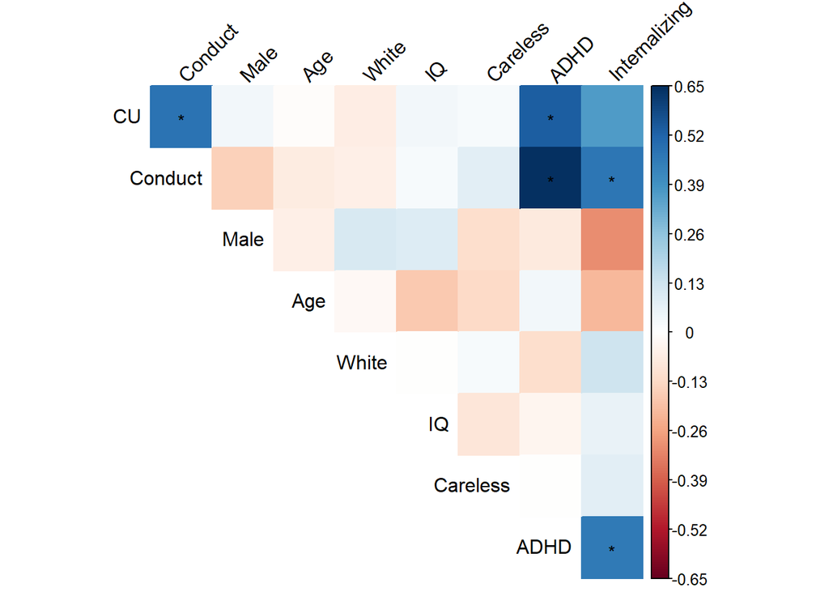

```r
colnames(dem_cor_r) <- c("CU", "Conduct", "Male", "Age", "White", "IQ", "Careless", "ADHD", "Internalizing")
rownames(dem_cor_r) <- c("CU", "Conduct", "Male", "Age", "White", "IQ", "Careless", "ADHD", "Internalizing")
colnames(dem_cor_p) <- c("CU", "Conduct", "Male", "Age", "White", "IQ", "Careless", "ADHD", "Internalizing")
rownames(dem_cor_p) <- c("CU", "Conduct", "Male", "Age", "White", "IQ", "Careless", "ADHD", "Internalizing")

dem_cor_r<-data.matrix(dem_cor_r)
diag(dem_cor_r)=0

corrplot::corrplot(
  dem_cor_r,
  method = "color",
  type="upper",
  diag=FALSE,
  tl.col="black",
  p.mat = data.matrix(dem_cor_p),
  tl.srt=45,
  sig.level = c(0.05),
  pch.cex=0.9,
  insig = "label_sig",
  col.lim=c(-0.65, 0.65),
  is.corr=FALSE
  )
```

```r
# not saved during kniting document because is causes error
# ggsave(
#   paste0(base_fig,"\\demographic_correlation.tiff"),
#   plot = last_plot(),
#   device = "tiff",
#   scale = 1,
#   width = 5,
#   height = 5,
#   units = "in",
#   dpi = 300
# )
```

## 2.4 Phenotypic Correlations

- Correlations showing phenotypic associations to characterize sample
- here we are substantiating that the antisocial prototypes in this sample
  - positively associate with delinquency
  - negatively associate with prosociality and reflective functioning

```r
phen_cor <- corrplot::cor.mtest(
  dat[-which(dat$careless>0),c(
    "cu_total_sum",
    "sdq_cd",
    "delq_total_sum",
    "sdq_prosocial",
    "rfq_total")])
phen_cor_p <- as.data.frame(phen_cor$p)
phen_cor_r <- as.data.frame((phen_cor$lowCI+phen_cor$uppCI)/2)

# Saving Values

write.csv(
  phen_cor_p,
  paste0(base,"\\phenotype_cor_pvalue.csv"),
  row.names=TRUE
)

write.csv(
  phen_cor_r,
  paste0(base,"\\phenotype_cor_Rvalue.csv"),
  row.names=TRUE
)
```

### 2.4.1 Correlation figure

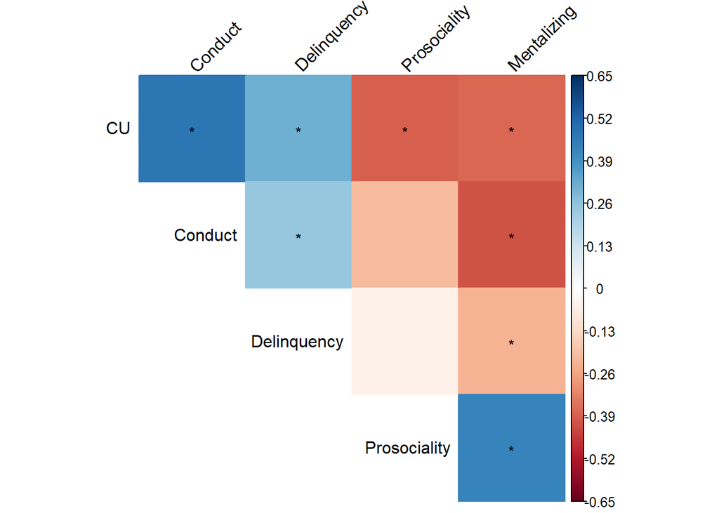

```r
colnames(phen_cor_r) <- c("CU", "Conduct", "Delinquency", "Prosociality", "Mentalizing")
rownames(phen_cor_r) <- c("CU", "Conduct", "Delinquency", "Prosociality", "Mentalizing")
colnames(phen_cor_p) <- c("CU", "Conduct", "Delinquency", "Prosociality", "Mentalizing")
rownames(phen_cor_p) <- c("CU", "Conduct", "Delinquency", "Prosociality", "Mentalizing")

phen_cor_r<-data.matrix(phen_cor_r)
diag(phen_cor_r)=0

corrplot::corrplot(
  phen_cor_r,
  method = "color",
  type="upper",
  diag=FALSE,
  tl.col="black",
  p.mat = data.matrix(phen_cor_p),
  tl.srt=45,
  sig.level = c(0.05),
  pch.cex=0.9,
  insig = "label_sig",
  col.lim=c(-0.65, 0.65),
  is.corr = FALSE
  )
```

```r
# not saved during kniting document because is causes error
# ggsave(
#   paste0(base_fig,"\\phenotype_correlation.tiff"),
#   plot = last_plot(),
#   device = "tiff",
#   scale = 1,
#   width = 5,
#   height = 5,
#   units = "in",
#   dpi = 300
# )
```

## 2.5 Variance retained

- here we are testing how much variance is retained after removing variance in externalizing variables
  - CU
  - Conduct
  - ADHD
- we want to make sure we still have adequate variance to estimate our models

```r
xz <- dem_cor_r[1,8] # correlation from CU to conduct
yz <- dem_cor_r[2,8] # correlation from conduct to ADHD
xy <- dem_cor_r[1,2] # correlation between CU and conduct

# shared correlation
Rxyz <- sqrt((abs(xz**2) + abs(yz**2) - 2*(xz*yz*xy)) / (1-abs(xy**2)))
# varaince explained R2
R2xyz <- Rxyz**2
# variance retained in CU and conduct
1-R2xyz
```

```
## [1] 0.5181617
```

- we retained > 50% of the variance in CU and conduct for estimation
  - this is adequate for model estimation

## 2.6 Baseline Comparisons

### 2.6.1 Theory of mind by group

- No baseline differences detected by group
  - this means differences are not driven by baseline Theory of mind ability

```r
  ## making statistical figures
    ## setting up dataframe with naming intact
ggstat_df <- dat
ggstat_df$cu_high[which(ggstat_df$cu_high==1)] <- "Clinical CU"
ggstat_df$cu_high[which(ggstat_df$cu_high==0)] <- "Normative CU"
ggstat_df$clin_cd <- clin_cd
ggstat_df$clin_cd[which(ggstat_df$clin_cd==1)] <- "Clinical CD"
ggstat_df$clin_cd[which(ggstat_df$clin_cd==0)] <- "Normative CD"
ggstat_df$clin_adhd <- clin_adhd
ggstat_df$clin_adhd[which(ggstat_df$clin_adhd==1)] <- "Clinical ADHD"
ggstat_df$clin_adhd[which(ggstat_df$clin_adhd==0)] <- "Normative ADHD"
ggstat_df$clin_internalizing <- clin_internalizing
ggstat_df$clin_internalizing[which(ggstat_df$clin_internalizing==1)] <- "Clinical Internalizing"
ggstat_df$clin_internalizing[which(ggstat_df$clin_internalizing==0)] <- "Normative Internalizing"
ggstat_df$group_names <- rep(0,length(ggstat_df$record_id))
ggstat_df$group_names[which(ggstat_df$group==1)] <- "Test: Single 1st"
ggstat_df$group_names[which(ggstat_df$group==2)] <- "Test: Dual 1st"
ggstat_df$group_names[which(ggstat_df$group==3)] <- "Control: Single 1st"
ggstat_df$group_names[which(ggstat_df$group==4)] <- "Control: Dual 1st"

ggstat_df$group_di_names <- rep(0,length(ggstat_df$record_id))
ggstat_df$group_di_names[which(ggstat_df$group_di==1)] <- "Test"
ggstat_df$group_di_names[which(ggstat_df$group_di==0)] <- "Control"
```

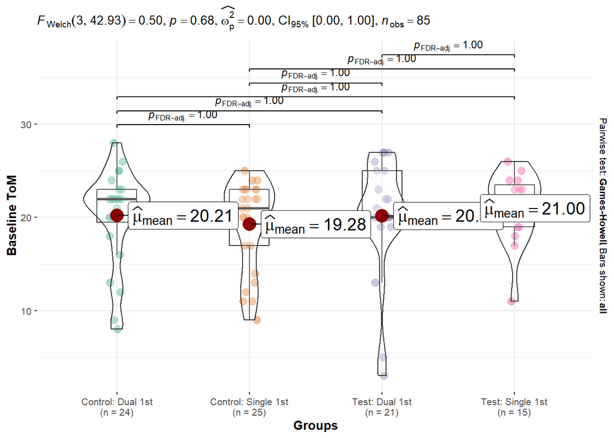

```r
  # Baseline ToM differences (no difference -- as expected)
    ### Violin demonstrating there are no ToM differences (for supplemental)
ggstatsplot::ggbetweenstats(
  data = ggstat_df,
  y = tom_s_acc_total_sum,
  x = group_names,
  ylab = "Baseline ToM",
  xlab = "Groups",
  results.subtitle = TRUE,
  p.adjust.method = "fdr",
  centrality.label.args = list(size=5, nudge_x = 0.5),
  pairwise.display = "all")
```

```r
ggsave(
  paste0(base_fig,"\\baseline_ToM.tiff"),
  plot = last_plot(),
  device = "tiff",
  scale = 1,
  width = 10,
  height = 7,
  units = "in",
  dpi = 300
)
```

### 2.6.2 Reaction time test vs. controls

- Test group has longer reaction time
  - This indicates that the task is working as expected

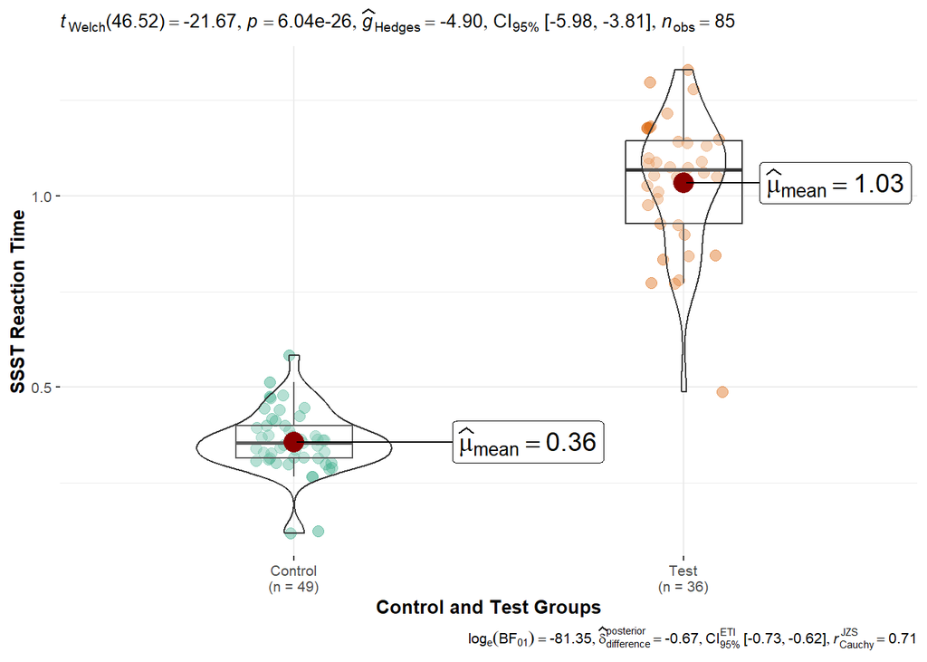

```r
  # ssst reaction time (test - control groups are different -- as expected)
    ## test has a longer RT than control - as expected (for supplemental)
ggstatsplot::ggbetweenstats(
  data = ggstat_df,
  y = ssst_mean_rt,
  x = group_di_names,
  ylab = "SSST Reaction Time",
  xlab = "Control and Test Groups",
  results.subtitle = TRUE,
  p.adjust.method = "fdr",
  centrality.label.args = list(size=5, nudge_x = 0.6),
  pairwise.display = "all")
```

```r
ggsave(
  paste0(base_fig,"\\ssst_rt_treat.tiff"),
  plot = last_plot(),
  device = "tiff",
  scale = 1,
  width = 6,
  height = 4,
  units = "in",
  dpi = 300
)
```

- Together this demonstrates that
- 1. baseline ToM is no different between groups
- 2. the loading task works as expected (longer reaction times for test group)

### 2.6.3 Phenotype by group

#### 2.6.3.1 CU

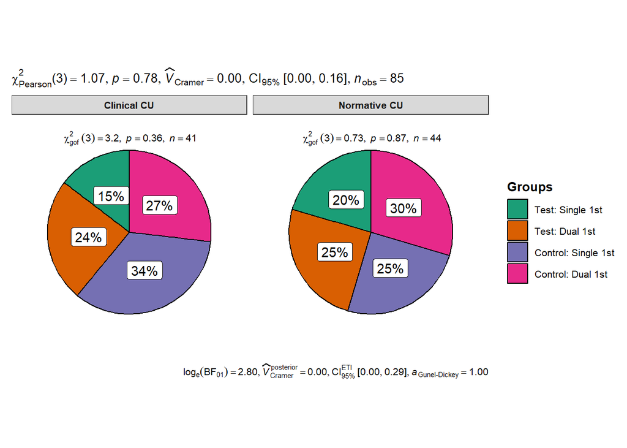

```r
ggstatsplot::ggpiestats(
  data = ggstat_df,
  y = cu_high,
  x = group_names,
  ylab = "Clinical Callous-Unemotional Traits",
  xlab = "Groups",
  legend.title = "Groups",
  results.subtitle = TRUE,
  p.adjust.method = "fdr",
  centrality.label.args = list(size=5, nudge_x = 0.5),
  pairwise.display = "all")
```

```r
ggsave(
  paste0(base_fig,"\\baseline_CU_by_group.tiff"),
  plot = last_plot(),
  device = "tiff",
  scale = 1,
  width = 10,
  height = 7,
  units = "in",
  dpi = 300
)
```

#### 2.6.3.2 CD

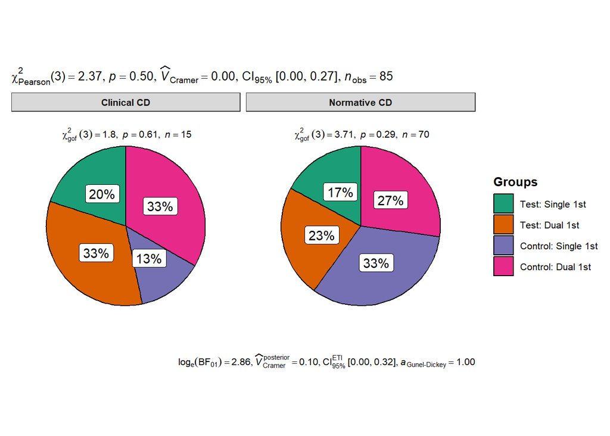

```r
ggstatsplot::ggpiestats(
  data = ggstat_df,
  y = clin_cd,
  x = group_names,
  ylab = "Clinical Conduct",
  xlab = "Groups",
  legend.title = "Groups",
  results.subtitle = TRUE,
  p.adjust.method = "fdr",
  centrality.label.args = list(size=5, nudge_x = 0.5),
  pairwise.display = "all")
```

```r
ggsave(
  paste0(base_fig,"\\baseline_CD_by_group.tiff"),
  plot = last_plot(),
  device = "tiff",
  scale = 1,
  width = 10,
  height = 7,
  units = "in",
  dpi = 300
)
```

#### 2.6.3.3 ADHD

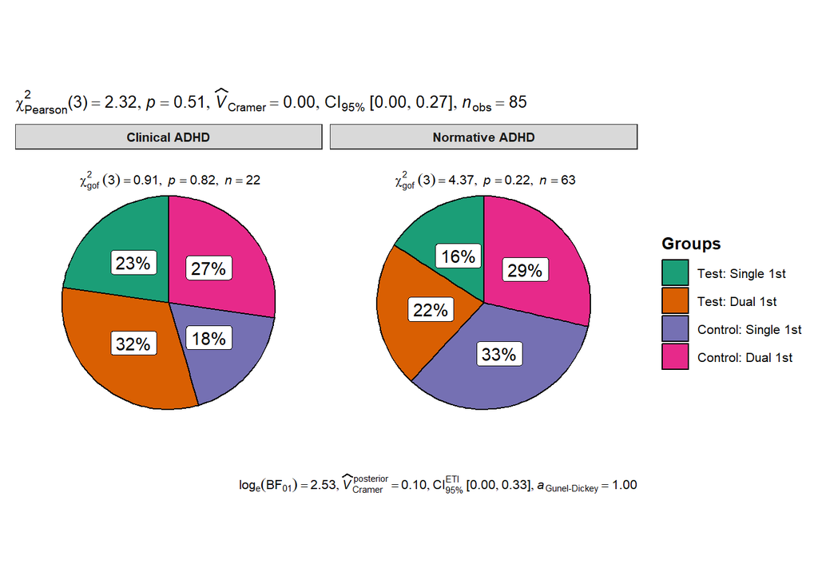

```r
ggstatsplot::ggpiestats(
  data = ggstat_df,
  y = clin_adhd,
  x = group_names,
  ylab = "Clinical ADHD",
  xlab = "Groups",
  legend.title = "Groups",
  results.subtitle = TRUE,
  p.adjust.method = "fdr",
  centrality.label.args = list(size=5, nudge_x = 0.5),
  pairwise.display = "all")
```

```r
ggsave(
  paste0(base_fig,"\\baseline_ADHD_by_group.tiff"),
  plot = last_plot(),
  device = "tiff",
  scale = 1,
  width = 10,
  height = 7,
  units = "in",
  dpi = 300
)
```

#### 2.6.3.4 Internalizing

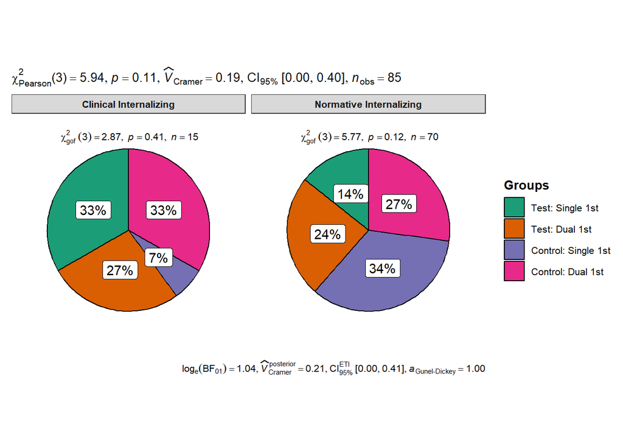

```r
ggstatsplot::ggpiestats(
  data = ggstat_df,
  y = clin_internalizing,
  x = group_names,
  ylab = "Clinical Internalizing",
  xlab = "Groups",
  legend.title = "Groups",
  results.subtitle = TRUE,
  p.adjust.method = "fdr",
  centrality.label.args = list(size=5, nudge_x = 0.5),
  pairwise.display = "all")
```

```r
ggsave(
  paste0(base_fig,"\\baseline_internalizing_by_group.tiff"),
  plot = last_plot(),
  device = "tiff",
  scale = 1,
  width = 10,
  height = 7,
  units = "in",
  dpi = 300
)
```

## 2.7 Measure Reliability

- loading item level responses data

```r
reliability_dat <- read.csv(reliability)
```

### 2.7.1 CU traits

#### 2.7.1.1 CFA

- note we use 22 items and remove 2 items for poor psychometrics
  - see: https://doi.org/10.1111/jcpp.12357

```r
mod_bi <- "
callous =~ icu4 + icu7 + icu8 + icu9 + icu11 + icu12 + icu18 + icu20 + icu21
uncaring =~ icu3 + icu5 + icu13 + icu15 + icu16 + icu17 + icu23 + icu24
unemotional =~ icu1 + icu6 + icu14 + icu19 + icu22

## bifactor
cu =~ icu4 + icu7 + icu8 + icu9 + icu11 + icu12 + icu18 + icu20 + icu21 + icu3 + icu5 + icu13 + icu15 + icu16 + icu17 + icu23 + icu24 + icu1 + icu6 + icu14 + icu19 + icu22

## uncorrelating bifactor from subscales
cu ~~ 0*callous + 0*uncaring + 0*unemotional

## correlating residuals based on modification indicies
  # within factor residual correlations
    # primarily positive worded items (e.g., Kemp et al. 2022)
icu17 ~~ icu24
icu4 ~~ icu18
icu14 ~~ icu19
icu3 ~~ icu16
icu7 ~~ icu20
icu8 ~~ icu18
icu5 ~~ icu17
icu1 ~~ icu14
icu12 ~~ icu21

"

## Fitting bifactor model to view loadings
fit_bi <- cfa(
  mod_bi,
  data=reliability_dat,
  estimator = "ML",
  missing = "FIML"
  )

## fit measures
fitmeasures(
  fit_bi,
  output = "matrix",
  fit.measures = c("chisq", "df", "pvalue", "tli", "cfi", "rmsea", "srmr")
  )
```

```
##
## chisq  267.817
## df     175.000
## pvalue   0.000
## tli      0.808
## cfi      0.855
## rmsea    0.072
## srmr     0.083
```

- model fit is commensurate with previous factor analyses
  - https://doi.org/10.1016/j.ijlp.2008.04.002
  - https://doi.org/10.1007%2Fs10862-012-9315-4

#### 2.7.1.2 Omega (w)

```r
omega_cu<-as.data.frame(
  omega(
    reliability_dat[,
            which(
              startsWith(
                colnames(reliability_dat),
                "icu"
                )
              )][,c(1:10,11:14,16:24)], # selecting 22 items use in CFA
    nfactors = 3,
    plot = FALSE)$omega.group$total
)
colnames(omega_cu) <- "omega_cu"
rownames(omega_cu) <- c("Overall", "Callous", "Unemotional", "Uncaring")
format(omega_cu, digits=3)
```

|  | omega_cu |
| --- | --- |
| Overall | 0.861 |
| Callous | 0.837 |
| Unemotional | 0.724 |
| Uncaring | 0.675 |

- Overall omega is > 0.70 indicating the use of a total score is reliable

### 2.7.2 SDQ

#### 2.7.2.1 CFA

```r
## bi-factor model
sdq_bi <- "
emotional =~ sdq3 + sdq8 + sdq13 + sdq16 + sdq24
conduct =~ sdq5 + sdq7 + sdq12 + sdq18 + sdq22
hyperactivity =~ sdq2 + sdq10 + sdq15 + sdq21 + sdq25
peer =~ sdq6 + sdq11 + sdq14 + sdq19 + sdq23
prosocial =~ sdq1 + sdq4 + sdq9 + sdq17 + sdq20

## bifactor
sdq =~ sdq4 + sdq7 + sdq8 + sdq9 + sdq11 + sdq12 + sdq18 + sdq20 + sdq21 + sdq3 + sdq5 + sdq13 + sdq15 + sdq16 + sdq17 + sdq23 + sdq24 + sdq1 + sdq6 + sdq14 + sdq19 + sdq22 + sdq2 + sdq10 + sdq25

## uncorrelating bifactor from subscales
sdq ~~ 0*emotional + 0*conduct + 0*hyperactivity + 0*peer + 0*prosocial

"

# to fit the model
fit_sdq_bi <- cfa(
  sdq_bi,
  data=reliability_dat,
  estimator = "ML",
  missing = "FIML")

fitmeasures(
  fit_sdq_bi,
  output = "matrix",
  fit.measures = c("chisq", "df", "pvalue", "tli", "cfi", "rmsea", "srmr")
  )
```

```
##
## chisq  276.927
## df     240.000
## pvalue   0.051
## tli      0.931
## cfi      0.945
## rmsea    0.039
## srmr     0.063
```

#### 2.7.2.2 Omega (w)

##### 2.7.2.2.1 Five factors

```r
omega_sdq<-as.data.frame(
  omega(
    reliability_dat[,which(startsWith(colnames(reliability_dat), "sdq"))][,1:25],
    covar=TRUE,
    nfactors = 5,
    plot = FALSE)$omega.group$total
  )
colnames(omega_sdq) <- "omega_sdq"
rownames(omega_sdq) <- c("Overall", "Hyperactivity", "Conduct", "Peer", "Prosocial","Emotional")
format(omega_sdq, digits=3)
```

|  | omega_sdq |
| --- | --- |
| Overall | 0.910 |
| Hyperactivity | 0.847 |
| Conduct | 0.770 |
| Peer | 0.611 |
| Prosocial | 0.683 |
| Emotional | 0.575 |

- omega for hyperactivity and conduct are adequate (> 0.70)
  - so the use of these subscales is indicated as reliable measures
- But internalizing factors are no (<0.70)
  - so peer and emotional subscales are marginally reliable
- Since we only use internalizing factors as a total internalizing factor
  - lets look to see if the general internalizing factor is reliable

##### 2.7.2.2.2 In/Externalizing factors

```r
omega_sdq_ext_int<-as.data.frame(
  omega(
    reliability_dat[,which(startsWith(colnames(reliability_dat), "sdq"))][,1:25],
    covar=TRUE,
    nfactors = 2,
    two.ok = TRUE,
    option = "equal",
    plot = FALSE)$omega.group$total
)
colnames(omega_sdq_ext_int) <- "omega_sdq_ext_int"
rownames(omega_sdq_ext_int) <- c("Overall", "Externalizing", "Internalizing")
format(omega_sdq_ext_int, digits=3)
```

|  | omega_sdq_ext_int |
| --- | --- |
| Overall | 0.889 |
| Externalizing | 0.819 |
| Internalizing | 0.779 |

- Internalizing is reliable (> 0.70)

# 3 A Priori Power Analysis

## 3.1 Constructing Model

```r
# Set seed for reproducibility
set.seed(123)

# Define parameters for the simulation
n_individuals <- 85  # Number of participants
n_timepoints <- 2    # Number of time points
n <- n_individuals * n_timepoints

# Simulate individual-level data
individuals <- rep(1:n_individuals, each = n_timepoints)
time <- rep(1:n_timepoints, times = n_individuals)  # Two time points (1, 2)
treatment <- rep(c(0, 1), each = n / 2)  # Binary treatment variable (0, 1)
phenotype <- rnorm(n_individuals, mean = 0, sd = 1)  # Continuous phenotype
phenotype <- rep(phenotype, each = n_timepoints)  # Repeated phenotype
phenotype2 <- rep(rnorm(n_individuals, mean = 0, sd = 0.5), each = n_timepoints)
order <- c(rep(c(0, 1), each = n / 4),(0))
order <- c(order,order)
iqs <- rep(rnorm(n_individuals, mean=100, sd=1), each = n_timepoints)
control1 <- rep(rnorm(n_individuals, mean=5, sd=1.1),each = n_timepoints)
control2 <- rep(rnorm(n_individuals, mean=2, sd=0.8),each = n_timepoints)

# Set fixed effects coefficients
beta_0 <- 10  # Intercept
beta_time <- 1  # Effect of time
beta_treatment <- 2  # Effect of treatment
beta_phenotype <- -1  # Effect of phenotype (continuous)
beta_interaction <- 1.5  # Effect of treatment*time*phenotype interaction
sigma_individual <- 1.5  # Random intercept variance for individuals
sigma_residual <- 1.0  # Residual standard deviation

# Create the response variable with interaction effect
y <- beta_0 +
  beta_time * (time - 1) +  # Center time to avoid multicollinearity
  beta_treatment * treatment +
  beta_phenotype * phenotype +
  beta_interaction * treatment * (time - 1) * phenotype +  # Interaction term
  rnorm(n, 0, sigma_individual) +  # Random intercept noise
  rnorm(n, 0, sigma_residual)  # Residual noise

# Create data frame
sim_data <- data.frame(
  y = y,
  time = factor(time),
  treatment = factor(treatment),
  phenotype = scale(phenotype, center = TRUE, scale = FALSE),  # Centered
  phenotype2 = scale(phenotype2, center = TRUE, scale = FALSE),  # Centered
  order = factor(order),
  individual = factor(individuals),
  iqs = scale(iqs, center = TRUE, scale = FALSE),  # Centered
  control1 = scale(control1, center = TRUE, scale = FALSE),  # Centered
  control2 = scale(control2, center = TRUE, scale = FALSE)  # Centered
)

# creating residualized interactions like we intend with the full model
  # group x time
sim_data$int_timegp <- resid(
  lm(I(as.numeric(treatment)*as.numeric(time)) ~
       as.numeric(treatment)+as.numeric(time), data=sim_data)
  )

  # phenotype x phenotype2
sim_data$int_phenotype2phenotype <- resid(
  lm(I(phenotype2*phenotype) ~ phenotype2+phenotype, data=sim_data)
  )
sim_data$int_phenotype2phenotypegp <- resid(
  lm(I(phenotype2*phenotype*as.numeric(treatment)) ~
       phenotype2+phenotype+as.numeric(treatment), data=sim_data)
  )
sim_data$int_phenotype2phenotypetime <- resid(
  lm(I(phenotype2*phenotype*as.numeric(treatment)*as.numeric(time)) ~
       phenotype2+phenotype+as.numeric(treatment)+as.numeric(time),
     data=sim_data)
  )
sim_data$int_phenotype2phenotypegptime <- resid(
  lm(I(phenotype2*phenotype*as.numeric(time)) ~
       phenotype2+phenotype+as.numeric(time), data=sim_data)
  )

  # phenotype
sim_data$int_phenotypegp <- resid(
  lm(I(phenotype*as.numeric(treatment)) ~
       phenotype+as.numeric(treatment), data=sim_data)
  )
sim_data$int_phenotypetime <- resid(
  lm(I(phenotype*as.numeric(time)) ~
       phenotype+as.numeric(time), data=sim_data)
  )
sim_data$interaction_phenotype_time_treat <- resid(
  lm(I(phenotype*as.numeric(treatment)*as.numeric(time)) ~
       phenotype+as.numeric(treatment)+as.numeric(time), data=sim_data)
  )

  # phenotype2
sim_data$int_phenotype2gp <- resid(
  lm(I(phenotype2*as.numeric(treatment)) ~
       phenotype2+as.numeric(treatment), data=sim_data)
  )
sim_data$int_phenotype2time <- resid(
  lm(I(phenotype2*as.numeric(time)) ~
       phenotype2+as.numeric(time), data=sim_data)
  )
sim_data$int_phenotype2timegp <- resid(
  lm(I(phenotype2*as.numeric(treatment)*as.numeric(time)) ~
       phenotype2+as.numeric(treatment)+as.numeric(time), data=sim_data)
  )

# Fit the mixed model accounting for individual variance
power_model <- lmer(
  y ~
    time +
    treatment +
    phenotype +
    phenotype2 +
    int_timegp +
    int_phenotype2phenotype +
    int_phenotype2phenotypegp +
    int_phenotype2phenotypegptime +
    int_phenotypegp +
    int_phenotypetime +
    interaction_phenotype_time_treat +
    int_phenotype2gp +
    int_phenotype2time +
    int_phenotype2timegp +
    iqs +
    control1 +
    control2 +
    (1 | individual),
  data = sim_data,
  control = control)
```

## 3.2 Power analysis

```r
power_curve <- powerCurve(
  power_model,
  nsim = 100,
  seed = 1979,
  breaks = c(
    10*n_timepoints,
    30*n_timepoints,
    50*n_timepoints,
    65*n_timepoints,
    80*n_timepoints
    ),
  along = "interaction_phenotype_time_treat"
  )
```

```
## Power for predictor 'time', (95% confidence interval),
## by largest value of interaction_phenotype_time_treat:
## -0.89253793046319:  0.00% ( 0.00,  7.32) - 20 rows
## -0.163978128824824: 37.00% (22.08, 53.90) - 60 rows
## 0.0816191720825863: 87.00% (72.76, 95.56) - 100 rows
## 0.340634698866774: 99.00% (90.44, 100.00) - 130 rows
## 1.6254081103551: 100.0% (92.68, 100.0) - 160 rows
##
## Time elapsed: 0 h 0 m 33 s
```

- Require at least 50 (100/2 time points) participants for ~80% power (ci < 80)
  - sample of 80 (160/2 time points) affords >90% power (lower ci > 90)
  - test effects can be reliably estimated with current sample
  - by modeling repeated measures mixed effects

# 4 Primary Analysis

- **Preregistration**
  - https://doi.org/10.17605/OSF.IO/BHWEU
- **General approach**
  - we use random effects modeling with a repeated measures design
  - we build on this by using a random effect block bootstrap to build confidence in our estimates
- **Random effects modeling**
  - allows us to model individual variation as a source of error across repeated measures and account for correlation between time points
- **Random effect block bootstrapping**
  - allows us to loosen assumptions on our model so as to not influence outcomes based on imposed assumptions
  - allows us to more accurately estimate our interaction terms (given interactions can induce non-normality and influence results)
  - allows us to correct mixed effect modeling assumption errors (residual distribution and autocorrelation)
  - such an approach is critical when control participants are expected to be the same across repeated measures
- **Important assumptions we assess and address**:
  - see: https://doi.org/10.1177/1094428119877457
  - Our IVs do not depend on the DV (we want exogeneity not endogeneity)
  - autocorrelation, heteroskedasticity, residual distribution, outliers that influence results

## 4.1 **Change in ToM - Accuracy**

### 4.1.1 **Overall** ToM *Accuracy*

#### 4.1.1.1 Model

```r
total_mix_p <- lmer(tom_acc_total  ~
                      cu +
                      sdq_cd +
                      sex_male +
                      race_white +
                      iq +
                      careless +
                      sdq_hyperactivity +
                      sdq_internalizing +
                      time +
                      group_di +
                      order_var +
                      int_gptime +
                      int_cdcu +
                      int_cdcugp +
                      int_cdcugptime +
                      int_cugp +
                      int_cugptime +
                      int_cdgp +
                      int_cdgptime +
                      (1|id),
                    data = dat_long
                    )
```

#### 4.1.1.2 Assumption check

```r
assumptions(total_mix_p, dat_long)
```

```
##  Convergence:      OK: Model Converged
##  Singularity:      OK: Model Not Singular
##  Heteroscedacity:  OK: Error variance appears to be homoscedastic (p = 0.135).
##  Autocorrelation:  OK: Residuals appear to be independent and not autocorrelated (p = 0.230).
##  Residual dist:    OK: Simulated residuals appear as uniformly distributed (p = 0.158).
##  Multicollinerity: OK: No Multicollinearity (All IVs VIF < 3)
##  Endogenity:       OK: IVs are exogenous (p > 0.05)
##  Random effects:   OK: Random effects indicated
##  Outliers:         OK: No outliers detected.
## - Based on the following method and threshold: cook (1).
## - For variable: (Whole model)
```

#### 4.1.1.3 Model performance

```r
(total_mix_p_st <- performance(total_mix_p))
```

| AIC | AICc | BIC | R2_conditional | R2_marginal | ICC | RMSE | Sigma |
| --- | --- | --- | --- | --- | --- | --- | --- |
| 906.5162 | 913.4005 | 975.5038 | 0.8103326 | 0.1922807 | 0.7651815 | 1.643266 | 2.267135 |

#### 4.1.1.4 Results (boostrap corrected)

```r
# summary(total_mix_p)
(tom_total_df <- mix_boot_report(total_mix_p))
```

|  | beta.boot | se.boot | t.boot | p.satw_boot | ci.boot_low | ci.boot_hi |
| --- | --- | --- | --- | --- | --- | --- |
| (Intercept) | 11.3388 | 3.2999 | 3.2676 | 0.00168 | 4.82e+00 | 17.79683 |
| cu | 0.3256 | 2.0341 | 0.1540 | 0.87805 | -3.76e+00 | 4.25583 |
| sdq_cd | -4.5424 | 2.0283 | -2.1204 | 0.03752 | -8.50e+00 | -0.56514 |
| sex_male | -0.0561 | 1.1244 | -0.0472 | 0.96248 | -2.29e+00 | 2.15043 |
| race_white | 1.5881 | 1.1712 | 1.2922 | 0.20055 | -6.45e-01 | 3.90793 |
| iq | 0.0595 | 0.0307 | 1.8188 | 0.07322 | -9.51e-04 | 0.11937 |
| careless | -1.9819 | 1.3248 | -1.4156 | 0.16132 | -4.62e+00 | 0.60487 |
| sdq_hyperactivity | 2.3735 | 1.3237 | 1.7076 | 0.09215 | -2.49e-01 | 4.96693 |
| sdq_internalizing | 1.5673 | 1.8575 | 0.8028 | 0.42479 | -2.11e+00 | 5.18406 |
| time | -0.7033 | 0.3528 | -2.1360 | 0.03578 | -1.39e+00 | -0.00815 |

[output cut: 17 more lines]

```r
# saving results to csv
write.csv(
  tom_total_df,
  tom_change_accuracy_total,
  row.names=TRUE
  )
```

#### 4.1.1.5 Figures

##### 4.1.1.5.1 Organizing plot data

```r
dat_plot <- dat_long
random.intercpet.preds_accuracy_total <- predict(total_mix_p)
dat_plot$hi_lo2<-ifelse(dat_plot$group_di == 0,"Control","Test")
dat_plot$time_rc<-ifelse(dat_plot$time == 0,"Single","Dual")
dat_plot$time_rc<-factor(dat_plot$time_rc, levels=c("Single","Dual"))
```

##### 4.1.1.5.2 CU and CD individual data plot

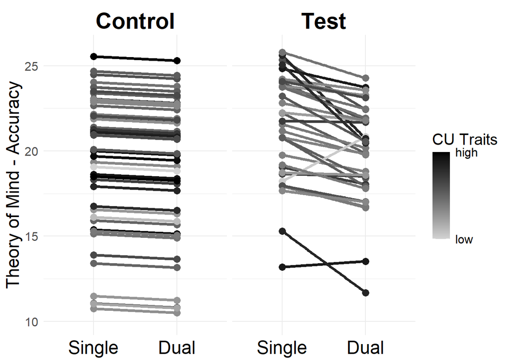

```r
  # CU_______
dat_plot %>%                 # data
  mutate(                    # to properly order control and test groups
    hi_lo = fct_relevel(
      hi_lo2,
      "Control",
      "Test")
    ) %>%
  ggplot(                   # plot
    aes(
      x=factor(time),
      y=random.intercpet.preds_accuracy_total,
      group = id,
      colour = cu)
    ) +
  geom_smooth(              # fit line
    method='lm',
    formula ='y ~ x',
    size=1.25
    ) +
  geom_point(size=3) +      # plot points
  labs(
    x=NULL,
    y="Theory of Mind - Accuracy"
    ) +
  scale_color_continuous(   # scale the color and labels accordingly
    "CU Traits",
    breaks = c(
      min(dat_plot$cu),
      max(dat_plot$cu)
      ),
    labels = c("low", "high"),
    type = "gradient",
    low="light grey",
    high="black"
    ) +
  ylim(10,26) +
  facet_wrap(~hi_lo)  +   # faceting plots by task (single ToM adn dual ToM)
  scale_x_discrete(
    labels=c(
      "Single",
      "Dual"
      )
    ) +
  theme_minimal() +       # setting theme and text parameters
  theme(
    axis.text=element_text(
      size=rel(1.1)
      ),
    axis.title=element_text(
      size=rel(1.6)
      ),
    strip.text.x.top = element_text(
      colour = "black",
      face = "bold",
      size=rel(2.5)
      ),
    axis.text.x = element_text(
      colour = "black",
      face="plain",
      size=rel(1.5)
      ),
    legend.title = element_text(
      size=rel(1.4)
      ),
    legend.text = element_text(
      size=rel(1.1)
      )
    )
```

```r
  # saving plot
ggsave(
  paste0(base_fig,"\\tom_total_accuracy_individual_line_CU.tiff"),
  plot = last_plot(),
  device = "tiff",
  scale = 1,
  width = 6,
  height = 7,
  units = "in",
  dpi = 300
)
```

##### 4.1.1.5.3 CU and CD by Task

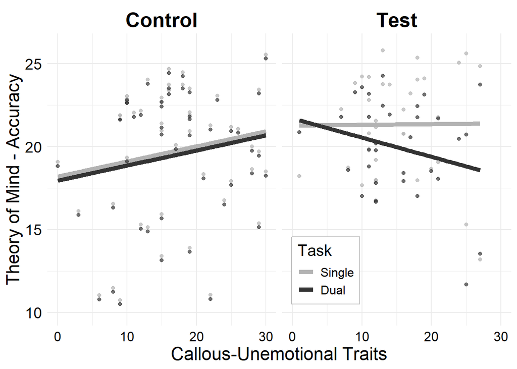

```r
  # CU______________
ggplot(
  data=dat_plot,
  aes(
    x=cu*22,                              # add denominator- rescale mean score
    y=random.intercpet.preds_accuracy_total,
    group = factor(time_rc),
    colour = factor(time_rc)
    )
  ) +
  geom_smooth(
    method='lm',
    se=FALSE,
    size=2
    ) +
  geom_point(alpha=0.7)+
  labs(
    x="Callous-Unemotional Traits",
    y="Theory of Mind - Accuracy"
    ) +
  scale_colour_grey(
    "Task",
    start = .7,
    end= .2
    ) +
  ylim(10,26) +
  facet_grid(. ~ fct_relevel(
    dat_plot$hi_lo2,
    "Control",
    "Test")
    ) +
  theme_minimal() +
  theme(
    axis.text=element_text(
      size=rel(1.1)
    ),
    axis.title=element_text(
      size=rel(1.6)
    ),
    strip.text.x.top = element_text(
      colour = "black",
      face = "bold",
      size=rel(2.25)
    ),
    axis.text.x = element_text(
      colour = "black",
      face="plain",
      size=rel(1.1)
    ),
    axis.text.y = element_text(
      colour = "black",
      face="plain",
      size=rel(1.2)
    ),
    legend.title = element_text(
      size=rel(1.4)
    ),
    legend.text = element_text(
      size=rel(1.1)
    ),
    legend.position = c(0.6,0.19),
    legend.background = element_rect(
      fill="white",
      color = "grey")
    )
```

```r
ggsave(
  paste0(base_fig,"\\tom_total_accuracy_task_line_CU.tiff"),
  plot = last_plot(),
  device = "tiff",
  scale = 1,
  width = 5.5,
  height = 4.5,
  units = "in",
  dpi = 300
)
```

### 4.1.2 **Affective** ToM *Accuracy*

#### 4.1.2.1 Model

```r
at_mix_p <- lmer(tom_acc_at  ~
                      cu +
                      sdq_cd +
                      sex_male +
                      race_white +
                      iq +
                      careless +
                      sdq_hyperactivity +
                      sdq_internalizing +
                      time +
                      group_di +
                      order_var +
                      int_gptime +
                      int_cdcu +
                      int_cdcugp +
                      int_cdcugptime +
                      int_cugp +
                      int_cugptime +
                      int_cdgp +
                      int_cdgptime +
                      (1|id),
                    data = dat_long
                    )
```

#### 4.1.2.2 Assumption check

```r
assumptions(at_mix_p, dat_long)
```

```
##  Convergence:      OK: Model Converged
##  Singularity:      OK: Model Not Singular
##  Heteroscedacity:  OK: Error variance appears to be homoscedastic (p = 0.577).
##  Autocorrelation:  OK: Residuals appear to be independent and not autocorrelated (p = 0.154).
##  Residual dist:    OK: Simulated residuals appear as uniformly distributed (p = 0.213).
##  Multicollinerity: OK: No Multicollinearity (All IVs VIF < 3)
##  Endogenity:       OK: IVs are exogenous (p > 0.05)
##  Random effects:   OK: Random effects indicated
##  Outliers:         OK: No outliers detected.
## - Based on the following method and threshold: cook (1).
## - For variable: (Whole model)
```

#### 4.1.2.3 Model performance

```r
(at_mix_p_st <- performance(at_mix_p))
```

| AIC | AICc | BIC | R2_conditional | R2_marginal | ICC | RMSE | Sigma |
| --- | --- | --- | --- | --- | --- | --- | --- |
| 687.0244 | 693.9087 | 756.0119 | 0.6637249 | 0.1649701 | 0.5972897 | 0.9596823 | 1.266249 |

#### 4.1.2.4 Results (boostrap corrected)

```r
# summary(at_mix_p)
(tom_at_df <- mix_boot_report(at_mix_p))
```

|  | beta.boot | se.boot | t.boot | p.satw_boot | ci.boot_low | ci.boot_hi |
| --- | --- | --- | --- | --- | --- | --- |
| (Intercept) | 4.7856 | 1.3367 | 3.5984 | 0.00059 | 2.11888 | 7.3712 |
| cu | -0.4543 | 0.8241 | -0.5536 | 0.58162 | -2.04950 | 1.1626 |
| sdq_cd | -1.7281 | 0.8347 | -2.0968 | 0.03962 | -3.35084 | -0.1100 |
| sex_male | -0.0103 | 0.4563 | -0.0229 | 0.98183 | -0.91725 | 0.8763 |
| race_white | 0.1771 | 0.4772 | 0.3781 | 0.70650 | -0.75526 | 1.1183 |
| iq | 0.0198 | 0.0125 | 1.5797 | 0.11869 | -0.00439 | 0.0443 |
| careless | -0.7394 | 0.5416 | -1.3843 | 0.17067 | -1.81247 | 0.3123 |
| sdq_hyperactivity | 0.7767 | 0.5368 | 1.4628 | 0.14800 | -0.28159 | 1.8209 |
| sdq_internalizing | 0.8416 | 0.7575 | 1.1275 | 0.26340 | -0.63314 | 2.3249 |
| time | -0.3273 | 0.1944 | -1.7007 | 0.09288 | -0.70966 | 0.0472 |

[output cut: 16 more lines]

```r
# saving results to csv
write.csv(
  tom_at_df,
  tom_change_accuracy_affective,
  row.names=TRUE
  )
```

#### 4.1.2.5 Figures

##### 4.1.2.5.1 Organizing plot data

```r
random.intercpet.preds_accuracy_at <- predict(at_mix_p)
```

##### 4.1.2.5.2 CU and CD by Task

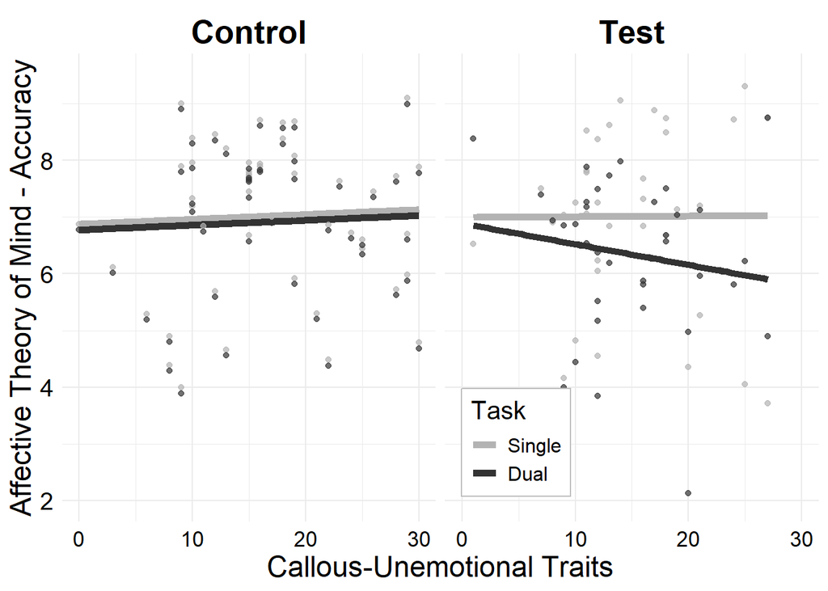

```r
  # CU______________
ggplot(
  data=dat_plot,
  aes(
    x=cu*22,                              # add demonstrator- rescale mean score
    y=random.intercpet.preds_accuracy_at,
    group = factor(time_rc),
    colour = factor(time_rc)
    )
  ) +
  geom_smooth(
    method='lm',
    se=FALSE,
    size=2
    ) +
  geom_point(alpha=0.7)+
  labs(
    x="Callous-Unemotional Traits",
    y="Affective Theory of Mind - Accuracy"
    ) +
  scale_colour_grey(
    "Task",
    start = .7,
    end= .2
    ) +
  ylim(2,9.5) +
  facet_grid(. ~ fct_relevel(
    dat_plot$hi_lo2,
    "Control",
    "Test")
    ) +
  theme_minimal() +
  theme(
    axis.text=element_text(
      size=rel(1.1)
    ),
    axis.title=element_text(
      size=rel(1.6)
    ),
    strip.text.x.top = element_text(
      colour = "black",
      face = "bold",
      size=rel(2.25)
    ),
    axis.text.x = element_text(
      colour = "black",
      face="plain",
      size=rel(1.1)
    ),
    axis.text.y = element_text(
      colour = "black",
      face="plain",
      size=rel(1.2)
    ),
    legend.title = element_text(
      size=rel(1.4)
    ),
    legend.text = element_text(
      size=rel(1.1)
    ),
    legend.position = c(0.60,0.17),
    legend.background = element_rect(
      fill="white",
      color = "grey")
    )
```

```r
ggsave(
  paste0(base_fig,"\\tom_affective_accuracy_task_line_CU.tiff"),
  plot = last_plot(),
  device = "tiff",
  scale = 1,
  width = 5.5,
  height = 4.5,
  units = "in",
  dpi = 300
)
```

### 4.1.3 **Cognitive** ToM *Accuracy*

#### 4.1.3.1 Model

```r
ct_mix_p <- lmer(tom_acc_ct  ~
                   cu +
                   sdq_cd +
                   sex_male +
                   race_white +
                   iq +
                   careless +
                   sdq_hyperactivity +
                   sdq_internalizing +
                   time +
                   group_di +
                   order_var +
                   int_gptime +
                   int_cdcu +
                   int_cdcugp +
                   int_cdcugptime +
                   int_cugp +
                   int_cugptime +
                   int_cdgp +
                   int_cdgptime +
                   (1|id),
                 data = dat_long
                 )
```

#### 4.1.3.2 Assumption check

[output not shown]

#### 4.1.3.3 Model performance

```r
(ct_mix_p_st <- performance(ct_mix_p))
```

| AIC | AICc | BIC | R2_conditional | R2_marginal | ICC | RMSE | Sigma |
| --- | --- | --- | --- | --- | --- | --- | --- |
| 665.412 | 672.2964 | 734.3996 | 0.6826658 | 0.1239938 | 0.6377489 | 0.8564597 | 1.142794 |

#### 4.1.3.4 Results (boostrap corrected)

```r
# summary(ct_mix_p)
(tom_ct_df <- mix_boot_report(ct_mix_p))
```

|  | beta.boot | se.boot | t.boot | p.satw_boot | ci.boot_low | ci.boot_hi |
| --- | --- | --- | --- | --- | --- | --- |
| (Intercept) | 3.4711 | 1.2877 | 2.5726 | 0.0122 | 0.97720 | 6.0003 |
| cu | 0.7605 | 0.7990 | 0.9146 | 0.3636 | -0.78374 | 2.3337 |
| sdq_cd | -1.1886 | 0.8051 | -1.4193 | 0.1602 | -2.78667 | 0.4087 |
| sex_male | -0.1708 | 0.4404 | -0.3698 | 0.7126 | -1.04036 | 0.7010 |
| race_white | 0.2607 | 0.4603 | 0.5478 | 0.5856 | -0.63558 | 1.1631 |
| iq | 0.0198 | 0.0119 | 1.5560 | 0.1242 | -0.00378 | 0.0427 |
| careless | -0.5416 | 0.5177 | -0.9967 | 0.3223 | -1.55726 | 0.4938 |
| sdq_hyperactivity | 0.6386 | 0.5182 | 1.1823 | 0.2411 | -0.38243 | 1.6539 |
| sdq_internalizing | 0.0802 | 0.7274 | 0.1060 | 0.9159 | -1.37318 | 1.5016 |
| time | -0.0480 | 0.1785 | -0.2886 | 0.7736 | -0.39803 | 0.3020 |

[output cut: 16 more lines]

```r
# saving results to csv
write.csv(
  tom_ct_df,
  tom_change_accuracy_cognitive,
  row.names=TRUE
  )
```

#### 4.1.3.5 Figures

##### 4.1.3.5.1 Organizing plot data

```r
random.intercpet.preds_accuracy_ct <- predict(ct_mix_p)
```

##### 4.1.3.5.2 CU and CD by Task

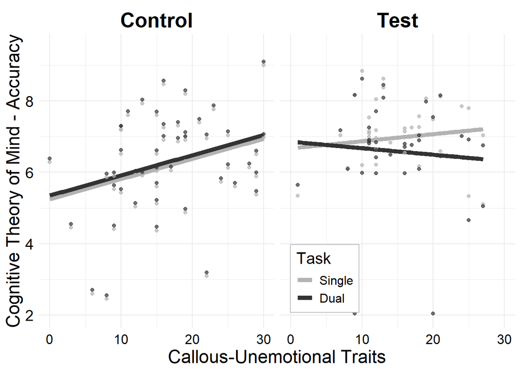

```r
  # CU______________
ggplot(
  data=dat_plot,
  aes(
    x=cu*22,                              # add demonstrator- rescale mean score
    y=random.intercpet.preds_accuracy_ct,
    group = factor(time_rc),
    colour = factor(time_rc)
    )
  ) +
  geom_smooth(
    method='lm',
    se=FALSE,
    size=2
    ) +
  geom_point(alpha=0.7)+
  labs(
    x="Callous-Unemotional Traits",
    y="Cognitive Theory of Mind - Accuracy"
    ) +
  scale_colour_grey(
    "Task",
    start = .7,
    end= .2
    ) +
  ylim(2,9.5) +
  facet_grid(. ~ fct_relevel(
    dat_plot$hi_lo2,
    "Control",
    "Test")
    ) +
  theme_minimal() +
  theme(
    axis.text=element_text(
      size=rel(1.1)
    ),
    axis.title=element_text(
      size=rel(1.6)
    ),
    strip.text.x.top = element_text(
      colour = "black",
      face = "bold",
      size=rel(2.25)
    ),
    axis.text.x = element_text(
      colour = "black",
      face="plain",
      size=rel(1.1)
    ),
    axis.text.y = element_text(
      colour = "black",
      face="plain",
      size=rel(1.2)
    ),
    legend.title = element_text(
      size=rel(1.4)
    ),
    legend.text = element_text(
      size=rel(1.1)
    ),
    legend.position = c(0.60,0.17),
    legend.background = element_rect(
      fill="white",
      color = "grey")
    )
```

```r
ggsave(
  paste0(base_fig,"\\tom_cognitive_accuracy_task_line_CU.tiff"),
  plot = last_plot(),
  device = "tiff",
  scale = 1,
  width = 5.5,
  height = 4.5,
  units = "in",
  dpi = 300
)
```

### 4.1.4 **Physical** ToM *Accuracy*

#### 4.1.4.1 Model

```r
pc_mix_p <- lmer(tom_acc_pc  ~
                   cu +
                   sdq_cd +
                   sex_male +
                   race_white +
                   iq +
                   careless +
                   sdq_hyperactivity +
                   sdq_internalizing +
                   time +
                   group_di +
                   order_var +
                   int_gptime +
                   int_cdcu +
                   int_cdcugp +
                   int_cdcugptime +
                   int_cugp +
                   int_cugptime +
                   int_cdgp +
                   int_cdgptime +
                   (1|id),
                 data = dat_long
                 )
```

#### 4.1.4.2 Assumption check

```
##  Convergence:      OK: Model Converged
##  Singularity:      OK: Model Not Singular
##  Heteroscedacity:  OK: Error variance appears to be homoscedastic (p = 0.367).
##  Autocorrelation:  OK: Residuals appear to be independent and not autocorrelated (p = 0.556).
##  Residual dist:    OK: Simulated residuals appear as uniformly distributed (p = 0.311).
##  Multicollinerity: OK: No Multicollinearity (All IVs VIF < 3)
##  Endogenity:       OK: IVs are exogenous (p > 0.05)
##  Random effects:   OK: Random effects indicated
##  Outliers:         OK: No outliers detected.
## - Based on the following method and threshold: cook (1).
## - For variable: (Whole model)
```

#### 4.1.4.3 Model performance

```r
(pc_mix_p_st <- performance(pc_mix_p))
```

| AIC | AICc | BIC | R2_conditional | R2_marginal | ICC | RMSE | Sigma |
| --- | --- | --- | --- | --- | --- | --- | --- |
| 666.9807 | 673.8651 | 735.9683 | 0.6900371 | 0.2057855 | 0.6097239 | 0.8864139 | 1.173651 |

#### 4.1.4.4 Results (boostrap corrected)

```r
# summary(pc_mix_p)
(tom_pc_df <- mix_boot_report(pc_mix_p))
```

|  | beta.boot | se.boot | t.boot | p.satw_boot | ci.boot_low | ci.boot_hi |
| --- | --- | --- | --- | --- | --- | --- |
| (Intercept) | 3.07123 | 1.2791 | 2.44826 | 0.0168 | 0.57637 | 5.5649 |
| cu | 0.00659 | 0.7851 | 0.00946 | 0.9925 | -1.52936 | 1.5437 |
| sdq_cd | -1.60997 | 0.7822 | -2.06969 | 0.0422 | -3.14032 | -0.1131 |
| sex_male | 0.12543 | 0.4291 | 0.29240 | 0.7708 | -0.71369 | 0.9615 |
| race_white | 1.15010 | 0.4455 | 2.59267 | 0.0116 | 0.29111 | 2.0296 |
| iq | 0.01997 | 0.0119 | 1.69180 | 0.0951 | -0.00336 | 0.0436 |
| careless | -0.70080 | 0.5046 | -1.38874 | 0.1693 | -1.68252 | 0.2806 |
| sdq_hyperactivity | 0.95752 | 0.5055 | 1.91089 | 0.0601 | -0.04517 | 1.9434 |
| sdq_internalizing | 0.64588 | 0.7071 | 0.91682 | 0.3624 | -0.75625 | 2.0171 |
| time | -0.32819 | 0.1788 | -1.84466 | 0.0688 | -0.67746 | 0.0246 |

[output cut: 16 more lines]

```r
# saving results to csv
write.csv(
  tom_pc_df,
  tom_change_accuracy_physical,
  row.names=TRUE
  )
```

#### 4.1.4.5 Figures

- none needed because nothing was significant

## 4.2 **Change in ToM - Reaction Time**

### 4.2.1 **Overall** ToM *Reaction Time*

#### 4.2.1.1 Model

```r
total_rt_mix_p <- lmer(tom_rt_total  ~
                         cu +
                         sdq_cd +
                         sex_male +
                         race_white +
                         iq +
                         careless +
                         sdq_hyperactivity +
                         sdq_internalizing +
                         time +
                         group_di +
                         order_var+
                         int_gptime +
                         int_cdcu +
                         int_cdcugp +
                         int_cdcugptime +
                         int_cugp +
                         int_cugptime +
                         int_cdgp +
                         int_cdgptime +
                         (1|id),
                       data = dat_long)
```

#### 4.2.1.2 Assumption check

```
##  Convergence:      OK: Model Converged
##  Singularity:      OK: Model Not Singular
##  Heteroscedacity:  OK: Error variance appears to be homoscedastic (p = 0.731).
##  Autocorrelation:  OK: Residuals appear to be independent and not autocorrelated (p = 0.674).
##  Residual dist:    OK: Simulated residuals appear as uniformly distributed (p = 0.518).
##  Multicollinerity: OK: No Multicollinearity (All IVs VIF < 3)
##  Endogenity:       OK: IVs are exogenous (p > 0.05)
##  Random effects:   OK: Random effects indicated
##  Outliers:         OK: No outliers detected.
## - Based on the following method and threshold: cook (1).
## - For variable: (Whole model)
```

#### 4.2.1.3 Model performance

```r
(total_rt_mix_p_st <- performance(total_rt_mix_p))
```

| AIC | AICc | BIC | R2_conditional | R2_marginal | ICC | RMSE | Sigma |
| --- | --- | --- | --- | --- | --- | --- | --- |
| 458.5951 | 465.4794 | 527.5826 | 0.5397274 | 0.06070047 | 0.5099832 | 0.487539 | 0.6272118 |

#### 4.2.1.4 Results (boostrap corrected)

```r
# summary(total_rt_mix_p)
(tom_rt_total_df <- mix_boot_report(total_rt_mix_p))
```

|  | beta.boot | se.boot | t.boot | p.satw_boot | ci.boot_low | ci.boot_hi |
| --- | --- | --- | --- | --- | --- | --- |
| (Intercept) | 2.44099 | 0.59152 | 4.2133 | 7.29e-05 | 1.26425 | 3.5894 |
| cu | 0.03134 | 0.36417 | 0.0879 | 9.30e-01 | -0.67993 | 0.7555 |
| sdq_cd | 0.18320 | 0.36305 | 0.5107 | 6.11e-01 | -0.54706 | 0.8874 |
| sex_male | -0.13109 | 0.20180 | -0.6650 | 5.08e-01 | -0.52572 | 0.2655 |
| race_white | -0.02174 | 0.20584 | -0.1068 | 9.15e-01 | -0.42267 | 0.3792 |
| iq | 0.00179 | 0.00551 | 0.3290 | 7.43e-01 | -0.00905 | 0.0127 |
| careless | -0.29687 | 0.23397 | -1.2786 | 2.05e-01 | -0.76108 | 0.1559 |
| sdq_hyperactivity | -0.00738 | 0.23493 | -0.0326 | 9.74e-01 | -0.47175 | 0.4579 |
| sdq_internalizing | -0.00155 | 0.33011 | -0.0023 | 9.98e-01 | -0.65073 | 0.6363 |
| time | 0.07062 | 0.09701 | 0.7444 | 4.59e-01 | -0.11991 | 0.2607 |

[output cut: 16 more lines]

```r
# saving results to csv
write.csv(
  tom_rt_total_df,
  tom_change_RT_total,
  row.names=TRUE
  )
```

#### 4.2.1.5 Figures

##### 4.2.1.5.1 Organizing plot data

```r
random.intercpet.preds_reaction_total <- predict(total_rt_mix_p)
```

##### 4.2.1.5.2 CU and CD individual data plot

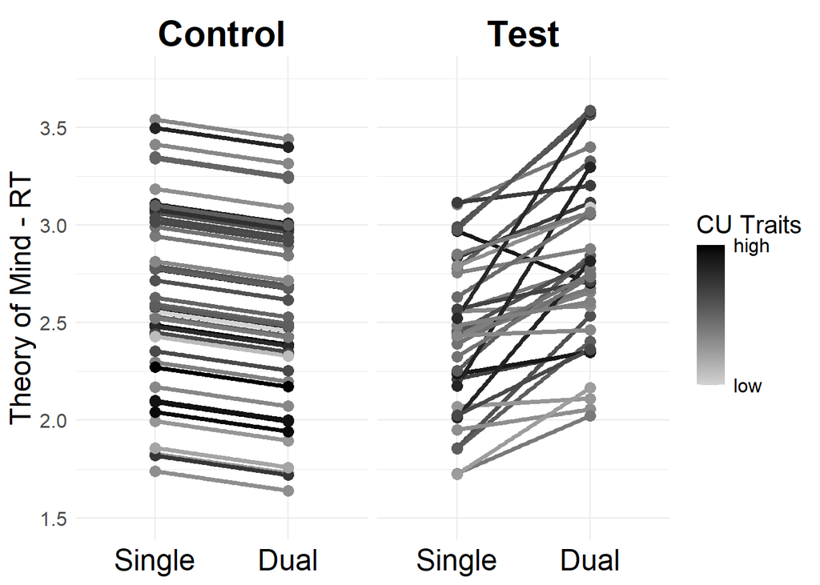

```r
  # CU_______
dat_plot %>%                 # data
  mutate(                    # to properly order control and test groups
    hi_lo = fct_relevel(
      hi_lo2,
      "Control",
      "Test")
    ) %>%
  ggplot(                   # plot
    aes(
      x=factor(time),
      y=random.intercpet.preds_reaction_total,
      group = id,
      colour = cu)
    ) +
  geom_smooth(              # fit line
    method='lm',
    formula ='y ~ x',
    size=1.25
    ) +
  geom_point(size=3) +      # plot points
  labs(
    x=NULL,
    y="Theory of Mind - RT"
    ) +
  scale_color_continuous(   # scale the color and labels accordingly
    "CU Traits",
    breaks = c(
      min(dat_plot$cu),
      max(dat_plot$cu)
      ),
    labels = c("low", "high"),
    type = "gradient",
    low="light grey",
    high="black"
    ) +
  ylim(1.5,3.75) +
  facet_wrap(~hi_lo)  +   # faceting plots by task (single ToM and dual ToM)
  scale_x_discrete(
    labels=c(
      "Single",
      "Dual"
      )
    ) +
  theme_minimal() +       # setting theme and text parameters
  theme(
    axis.text=element_text(
      size=rel(1.1)
      ),
    axis.title=element_text(
      size=rel(1.6)
      ),
    strip.text.x.top = element_text(
      colour = "black",
      face = "bold",
      size=rel(2.5)
      ),
    axis.text.x = element_text(
      colour = "black",
      face="plain",
      size=rel(1.5)
      ),
    legend.title = element_text(
      size=rel(1.4)
      ),
    legend.text = element_text(
      size=rel(1.1)
      )
    )
```

```r
  # saving plot
ggsave(
  paste0(base_fig,"\\tom_total_reaction_individual_line_CU.tiff"),
  plot = last_plot(),
  device = "tiff",
  scale = 1,
  width = 6,
  height = 7,
  units = "in",
  dpi = 300
)
```

##### 4.2.1.5.3 CU and CD by Task

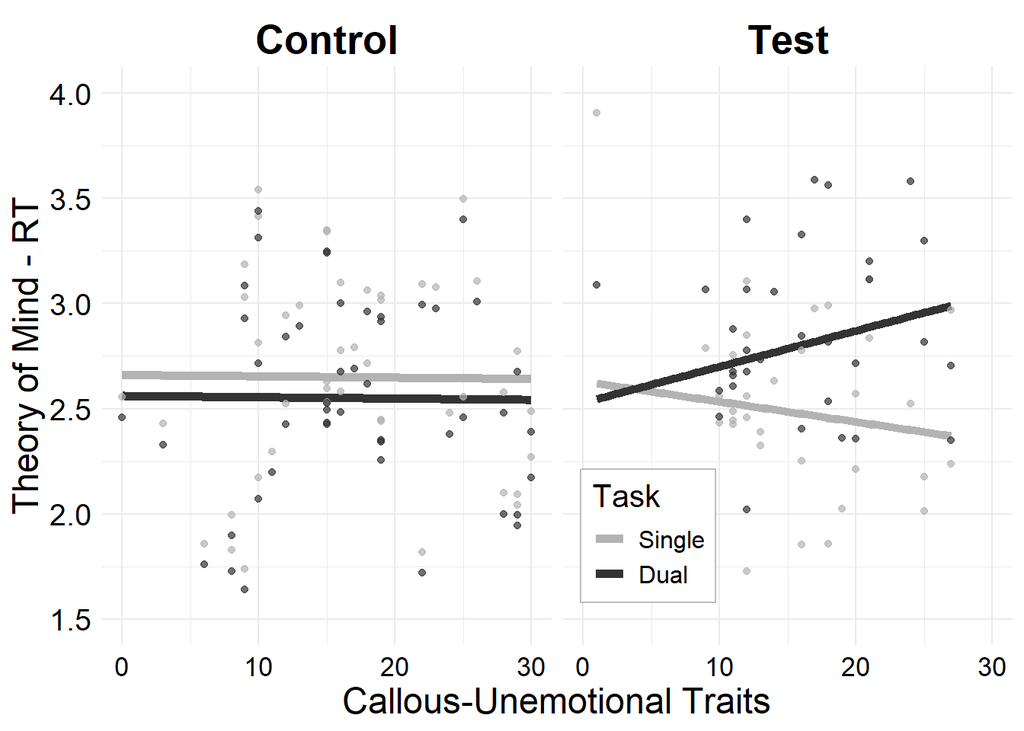

```r
  # CU______________
ggplot(
  data=dat_plot,
  aes(
    x=cu*22,                              # add denominator- rescale mean score
    y=random.intercpet.preds_reaction_total,
    group = factor(time_rc),
    colour = factor(time_rc)
    )
  ) +
  geom_smooth(
    method='lm',
    se=FALSE,
    size=2
    ) +
  geom_point(alpha=0.7)+
  labs(
    x="Callous-Unemotional Traits",
    y="Theory of Mind - RT"
    ) +
  scale_colour_grey(
    "Task",
    start = .7,
    end= .2
    ) +
  ylim(1.5,4) +
  facet_grid(. ~ fct_relevel(
    dat_plot$hi_lo2,
    "Control",
    "Test")
    ) +
  theme_minimal() +
  theme(
    axis.text=element_text(
      size=rel(1.1)
    ),
    axis.title=element_text(
      size=rel(1.6)
    ),
    strip.text.x.top = element_text(
      colour = "black",
      face = "bold",
      size=rel(2.25)
    ),
    axis.text.x = element_text(
      colour = "black",
      face="plain",
      size=rel(1.1)
    ),
    axis.text.y = element_text(
      colour = "black",
      face="plain",
      size=rel(1.2)
    ),
    legend.title = element_text(
      size=rel(1.4)
    ),
    legend.text = element_text(
      size=rel(1.1)
    ),
    legend.position = c(0.6,0.19),
    legend.background = element_rect(
      fill="white",
      color = "grey")
    )
```

```r
ggsave(
  paste0(base_fig,"\\tom_total_reaction_task_line_CU.tiff"),
  plot = last_plot(),
  device = "tiff",
  scale = 1,
  width = 5.5,
  height = 4.5,
  units = "in",
  dpi = 300
)
```

### 4.2.2 **Affective** ToM *Reaction Time*

#### 4.2.2.1 Model

```r
at_rt_mix_p <- lmer(tom_rt_at  ~
                         cu +
                         sdq_cd +
                         sex_male +
                         race_white +
                         iq +
                         careless +
                         sdq_hyperactivity +
                         sdq_internalizing +
                         time +
                         group_di +
                         order_var+
                         int_gptime +
                         int_cdcu +
                         int_cdcugp +
                         int_cdcugptime +
                         int_cugp +
                         int_cugptime +
                         int_cdgp +
                         int_cdgptime +
                         (1|id),
                       data = dat_long)
```

#### 4.2.2.2 Assumption check

```
##  Convergence:      OK: Model Converged
##  Singularity:      OK: Model Not Singular
##  Heteroscedacity:  OK: Error variance appears to be homoscedastic (p = 0.739).
##  Autocorrelation:  OK: Residuals appear to be independent and not autocorrelated (p = 0.446).
##  Residual dist:    OK: Simulated residuals appear as uniformly distributed (p = 0.326).
##  Multicollinerity: OK: No Multicollinearity (All IVs VIF < 3)
##  Endogenity:       OK: IVs are exogenous (p > 0.05)
##  Random effects:   OK: Random effects indicated
##  Outliers:         OK: No outliers detected.
## - Based on the following method and threshold: cook (1).
## - For variable: (Whole model)
```

#### 4.2.2.3 Model performance

```r
(at_rt_mix_p_st <- performance(at_rt_mix_p))
```

| AIC | AICc | BIC | R2_conditional | R2_marginal | ICC | RMSE | Sigma |
| --- | --- | --- | --- | --- | --- | --- | --- |
| 484.5741 | 491.4584 | 553.5617 | 0.5815945 | 0.06075446 | 0.5545302 | 0.5097092 | 0.6643824 |

#### 4.2.2.4 Results (boostrap corrected)

```r
# summary(at_rt_mix_p)
(tom_rt_at_df <- mix_boot_report(at_rt_mix_p))
```

|  | beta.boot | se.boot | t.boot | p.satw_boot | ci.boot_low | ci.boot_hi |
| --- | --- | --- | --- | --- | --- | --- |
| (Intercept) | 2.32625 | 0.66755 | 3.5660 | 0.000654 | 0.98825 | 3.6399 |
| cu | 0.11103 | 0.41017 | 0.2764 | 0.783070 | -0.69964 | 0.9329 |
| sdq_cd | 0.08530 | 0.41013 | 0.2115 | 0.833085 | -0.72576 | 0.8843 |
| sex_male | -0.10744 | 0.22738 | -0.4836 | 0.630205 | -0.54595 | 0.3421 |
| race_white | 0.07227 | 0.23245 | 0.3143 | 0.754236 | -0.38571 | 0.5290 |
| iq | 0.00310 | 0.00623 | 0.5055 | 0.614790 | -0.00914 | 0.0155 |
| careless | -0.31370 | 0.26372 | -1.2000 | 0.234189 | -0.82536 | 0.2083 |
| sdq_hyperactivity | 0.03745 | 0.26490 | 0.1435 | 0.886310 | -0.48496 | 0.5644 |
| sdq_internalizing | 0.01366 | 0.36950 | 0.0400 | 0.968228 | -0.69731 | 0.7364 |
| time | 0.06493 | 0.10248 | 0.6477 | 0.519005 | -0.13452 | 0.2648 |

[output cut: 16 more lines]

```r
# saving results to csv
write.csv(
  tom_rt_at_df,
  tom_change_RT_affective,
  row.names=TRUE
  )
```

#### 4.2.2.5 Figures

##### 4.2.2.5.1 Organizing plot data

```r
random.intercpet.preds_reaction_at <- predict(at_rt_mix_p)
```

##### 4.2.2.5.2 CU and CD by Task

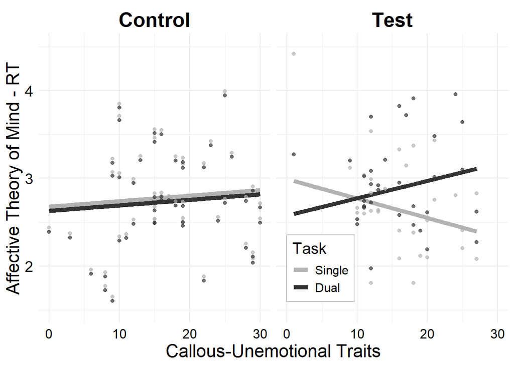

```r
  # CU______________
ggplot(
  data=dat_plot,
  aes(
    x=cu*22,                              # add denominator- rescale mean score
    y=random.intercpet.preds_reaction_at,
    group = factor(time_rc),
    colour = factor(time_rc)
    )
  ) +
  geom_smooth(
    method='lm',
    se=FALSE,
    size=2
    ) +
  geom_point(alpha=0.7)+
  labs(
    x="Callous-Unemotional Traits",
    y="Affective Theory of Mind - RT"
    ) +
  scale_colour_grey(
    "Task",
    start = .7,
    end= .2
    ) +
  ylim(1.5,4.5) +
  facet_grid(. ~ fct_relevel(
    dat_plot$hi_lo2,
    "Control",
    "Test")
    ) +
  theme_minimal() +
  theme(
    axis.text=element_text(
      size=rel(1.1)
    ),
    axis.title=element_text(
      size=rel(1.6)
    ),
    strip.text.x.top = element_text(
      colour = "black",
      face = "bold",
      size=rel(2.25)
    ),
    axis.text.x = element_text(
      colour = "black",
      face="plain",
      size=rel(1.1)
    ),
    axis.text.y = element_text(
      colour = "black",
      face="plain",
      size=rel(1.2)
    ),
    legend.title = element_text(
      size=rel(1.4)
    ),
    legend.text = element_text(
      size=rel(1.1)
    ),
    legend.position = c(0.6,0.19),
    legend.background = element_rect(
      fill="white",
      color = "grey")
    )
```

```r
ggsave(
  paste0(base_fig,"\\tom_affective_reaction_task_line_CU.tiff"),
  plot = last_plot(),
  device = "tiff",
  scale = 1,
  width = 5.5,
  height = 4.5,
  units = "in",
  dpi = 300
)
```

### 4.2.3 **Cognitive** ToM *Reaction Time*

#### 4.2.3.1 Model

```r
ct_rt_mix_p <- lmer(tom_rt_ct  ~
                         cu +
                         sdq_cd +
                         sex_male +
                         race_white +
                         iq +
                         careless +
                         sdq_hyperactivity +
                         sdq_internalizing +
                         time +
                         group_di +
                         order_var+
                         int_gptime +
                         int_cdcu +
                         int_cdcugp +
                         int_cdcugptime +
                         int_cugp +
                         int_cugptime +
                         int_cdgp +
                         int_cdgptime +
                         (1|id),
                       data = dat_long)
```

#### 4.2.3.2 Assumption check

```
##  Convergence:      OK: Model Converged
##  Singularity:      OK: Model Not Singular
##  Heteroscedacity:  OK: Error variance appears to be homoscedastic (p = 0.475).
##  Autocorrelation:  OK: Residuals appear to be independent and not autocorrelated (p = 0.948).
##  Residual dist:    OK: Simulated residuals appear as uniformly distributed (p = 0.609).
##  Multicollinerity: OK: No Multicollinearity (All IVs VIF < 3)
##  Endogenity:       OK: IVs are exogenous (p > 0.05)
##  Random effects:   OK: Random effects indicated
##  Outliers:         OK: No outliers detected.
## - Based on the following method and threshold: cook (1).
## - For variable: (Whole model)
```

#### 4.2.3.3 Model performance

```r
(ct_rt_mix_p_st <- performance(ct_rt_mix_p))
```

| AIC | AICc | BIC | R2_conditional | R2_marginal | ICC | RMSE | Sigma |
| --- | --- | --- | --- | --- | --- | --- | --- |
| 488.7573 | 495.6416 | 557.7448 | 0.5038494 | 0.08248345 | 0.4592461 | 0.5647178 | 0.7153623 |

#### 4.2.3.4 Results (boostrap corrected)

```r
# summary(ct_rt_mix_p)
(tom_rt_ct_df <- mix_boot_report(ct_rt_mix_p))
```

|  | beta.boot | se.boot | t.boot | p.satw_boot | ci.boot_low | ci.boot_hi |
| --- | --- | --- | --- | --- | --- | --- |
| (Intercept) | 2.33432 | 0.62970 | 3.7775 | 0.000326 | 1.09922 | 3.5680 |
| cu | 0.02248 | 0.38918 | 0.0584 | 0.953565 | -0.75014 | 0.7995 |
| sdq_cd | 0.21452 | 0.38574 | 0.5609 | 0.576665 | -0.55489 | 0.9621 |
| sex_male | -0.08266 | 0.21554 | -0.3939 | 0.694857 | -0.50383 | 0.3374 |
| race_white | -0.06498 | 0.21873 | -0.2990 | 0.765818 | -0.50048 | 0.3637 |
| iq | 0.00272 | 0.00587 | 0.4691 | 0.640485 | -0.00888 | 0.0143 |
| careless | -0.38820 | 0.24918 | -1.5678 | 0.121435 | -0.88167 | 0.0983 |
| sdq_hyperactivity | 0.08341 | 0.25036 | 0.3386 | 0.735927 | -0.40734 | 0.5800 |
| sdq_internalizing | -0.09583 | 0.35437 | -0.2751 | 0.784067 | -0.78968 | 0.5976 |
| time | 0.13045 | 0.10989 | 1.2087 | 0.230330 | -0.08525 | 0.3447 |

[output cut: 16 more lines]

```r
# saving results to csv
write.csv(
  tom_rt_ct_df,
  tom_change_RT_cognitive,
  row.names=TRUE
  )
```

#### 4.2.3.5 Figures

##### 4.2.3.5.1 Organizing plot data

```r
random.intercpet.preds_reaction_ct <- predict(ct_rt_mix_p)
```

##### 4.2.3.5.2 CU and CD by Task

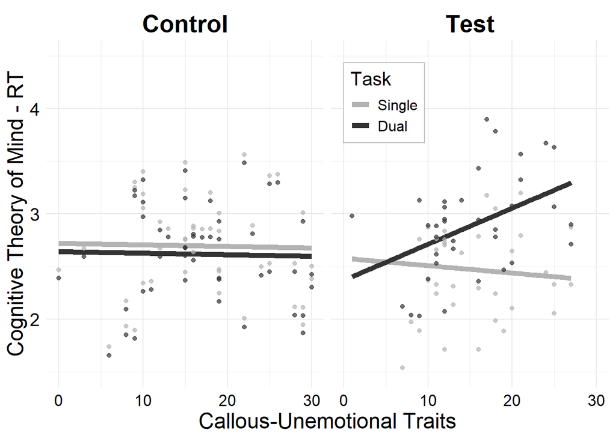

```r
  # CU______________
ggplot(
  data=dat_plot,
  aes(
    x=cu*22,                              # add denominator- rescale mean score
    y=random.intercpet.preds_reaction_ct,
    group = factor(time_rc),
    colour = factor(time_rc)
    )
  ) +
  geom_smooth(
    method='lm',
    se=FALSE,
    size=2
    ) +
  geom_point(alpha=0.7)+
  labs(
    x="Callous-Unemotional Traits",
    y="Cognitive Theory of Mind - RT"
    ) +
  scale_colour_grey(
    "Task",
    start = .7,
    end= .2
    ) +
  ylim(1.5,4.5) +
  facet_grid(. ~ fct_relevel(
    dat_plot$hi_lo2,
    "Control",
    "Test")
    ) +
  theme_minimal() +
  theme(
    axis.text=element_text(
      size=rel(1.1)
    ),
    axis.title=element_text(
      size=rel(1.6)
    ),
    strip.text.x.top = element_text(
      colour = "black",
      face = "bold",
      size=rel(2.25)
    ),
    axis.text.x = element_text(
      colour = "black",
      face="plain",
      size=rel(1.1)
    ),
    axis.text.y = element_text(
      colour = "black",
      face="plain",
      size=rel(1.2)
    ),
    legend.title = element_text(
      size=rel(1.4)
    ),
    legend.text = element_text(
      size=rel(1.1)
    ),
    legend.position = c(0.6,0.82),
    legend.background = element_rect(
      fill="white",
      color = "grey")
    )
```

```r
ggsave(
  paste0(base_fig,"\\tom_cognitive_reaction_task_line_CU.tiff"),
  plot = last_plot(),
  device = "tiff",
  scale = 1,
  width = 5.5,
  height = 4.5,
  units = "in",
  dpi = 300
)
```

### 4.2.4 **Physical** ToM *Reaction Time*

#### 4.2.4.1 Model

```r
pc_rt_mix_p <- lmer(tom_rt_pc  ~
                         cu +
                         sdq_cd +
                         sex_male +
                         race_white +
                         iq +
                         careless +
                         sdq_hyperactivity +
                         sdq_internalizing +
                         time +
                         group_di +
                         order_var+
                         int_gptime +
                         int_cdcu +
                         int_cdcugp +
                         int_cdcugptime +
                         int_cugp +
                         int_cugptime +
                         int_cdgp +
                         int_cdgptime +
                         (1|id),
                       data = dat_long)
```

#### 4.2.4.2 Assumption check

```
##  Convergence:      OK: Model Converged
##  Singularity:      OK: Model Not Singular
##  Heteroscedacity:  OK: Error variance appears to be homoscedastic (p = 0.832).
##  Autocorrelation:  OK: Residuals appear to be independent and not autocorrelated (p = 0.766).
##  Residual dist:    OK: Simulated residuals appear as uniformly distributed (p = 0.782).
##  Multicollinerity: OK: No Multicollinearity (All IVs VIF < 3)
##  Endogenity:       OK: IVs are exogenous (p > 0.05)
##  Random effects:   OK: Random effects indicated
##  Outliers:         OK: No outliers detected.
## - Based on the following method and threshold: cook (1).
## - For variable: (Whole model)
```

#### 4.2.4.3 Model performance

```r
(pc_rt_mix_p_st <- performance(pc_rt_mix_p))
```

| AIC | AICc | BIC | R2_conditional | R2_marginal | ICC | RMSE | Sigma |
| --- | --- | --- | --- | --- | --- | --- | --- |
| 453.2627 | 460.1471 | 522.2503 | 0.4041656 | 0.06592071 | 0.3621158 | 0.5467091 | 0.6712159 |

#### 4.2.4.4 Results (boostrap corrected)

```r
# summary(pc_rt_mix_p)
(tom_rt_pc_df <- mix_boot_report(pc_rt_mix_p))
```

|  | beta.boot | se.boot | t.boot | p.satw_boot | ci.boot_low | ci.boot_hi |
| --- | --- | --- | --- | --- | --- | --- |
| (Intercept) | 2.662531 | 0.52727 | 5.1347 | 2.35e-06 | 1.6450 | 3.69999 |
| cu | -0.039144 | 0.32342 | -0.1218 | 9.03e-01 | -0.6695 | 0.58976 |
| sdq_cd | 0.249506 | 0.32339 | 0.7779 | 4.39e-01 | -0.3989 | 0.87755 |
| sex_male | -0.203270 | 0.17989 | -1.1543 | 2.52e-01 | -0.5566 | 0.14175 |
| race_white | -0.072637 | 0.18465 | -0.3984 | 6.92e-01 | -0.4326 | 0.28804 |
| iq | -0.000446 | 0.00491 | -0.0913 | 9.27e-01 | -0.0101 | 0.00921 |
| careless | -0.189149 | 0.20869 | -0.9109 | 3.65e-01 | -0.5996 | 0.21195 |
| sdq_hyperactivity | -0.143192 | 0.20902 | -0.6947 | 4.90e-01 | -0.5523 | 0.27022 |
| sdq_internalizing | 0.077439 | 0.29490 | 0.2687 | 7.89e-01 | -0.5071 | 0.64586 |
| time | 0.016467 | 0.10416 | 0.1618 | 8.72e-01 | -0.1868 | 0.21910 |

[output cut: 16 more lines]

```r
# saving results to csv
write.csv(
  tom_rt_pc_df,
  tom_change_RT_physical,
  row.names=TRUE
  )
```

#### 4.2.4.5 Figures

- not necessary because nothing is significant

# 5 Secondary Analyses

- These analyses supplement the primary analysis by adding detail and context
- Here we will look at
  - Change between time points on contrasts between theory of mind conditions
  - Loading effects of the dual task
  - If change in affective ToM after load associates with delinquency
- For Contrasts we use the same approach as the Primary Analyses
  - We are testing change in these contrasts from single to dual task
- For loading effects we use a single timepoint approach
  - Instead of individual variation - we account for ordering random variance
- For association with delinquency
  - we use the same approach as above as we use a single timepoint approach
  - change between time points is a single metric

## 5.1 **Change in ToM - Contrasts**

### 5.1.1 Contrast considerations

- For accurate contrast estimation - we remove variance predicted by pc alone
  - We do this by subtracting pc from at and regressing out variance in pc
  - This is an indicated method redressing this issue
  - See: https://doi.org/10.1177/0013164412445473
  - We avoided pitfalls suggested by this article by not double conditioning
  - And only condition on the base of this contrast (here pc)
  - This accounts for random individual variation in the contrasted metric
  - And removes variance that cannot be explicitly be predicted by pc
- A subtraction score can bias results due to:
  - Collinearity - subtracting highly correlated variables
  - Loss of variance - subtracting two variables you loose individual variance
  - Retaining subtrahend variance - erroneous associations mimic the subtrahend
  - Model fit issues- this can erroneously alter relationship among predictors
- Conceptually - consider if at and pc are highly related
  - a subtraction method would retain variance that can be predicted by pc
  - if the subtraction score is highly related to pc - the metric is pc driven
- We demonstrate this concept below via correlations showing
  - 1. **ct and pc are highly related**
  - 2. **subtraction method *strongly related* to pc** - **(pc needs removed)**
  - 3. **subtraction method *not related* to ct** - **(no need to remove ct)**
  - 4. **residualized contrast doesn’t add non-normality or bias**
  - 5. **residualized contrast *removes confounding variance* of pc**
  - 6. **the residualized contrast represents the same contrast information**

#### 5.1.1.1 Subtraction concerns

##### 5.1.1.1.1 **Highly related variables**

```r
cor.test(dat_long$tom_acc_at, dat_long$tom_acc_pc)
```

```
##
##  Pearson's product-moment correlation
##
## data:  dat_long$tom_acc_at and dat_long$tom_acc_pc
## t = 7.4639, df = 168, p-value = 4.32e-12
## alternative hypothesis: true correlation is not equal to 0
## 95 percent confidence interval:
##  0.3768168 0.6041631
## sample estimates:
##      cor
## 0.499028
```

- at and pc variables are significantly and highly correlated
- a simple subtraction may introduce issues in our model
- but we still want to make sure removing pc variance is correct

##### 5.1.1.1.2 **Related to subtrahend**

```r
  # calculating subtraction
at_pc_diff_only <- (dat_long$tom_acc_at - dat_long$tom_acc_pc)
  # correlation
cor.test(dat_long$tom_acc_pc, at_pc_diff_only)
```

```
##
##  Pearson's product-moment correlation
##
## data:  dat_long$tom_acc_pc and at_pc_diff_only
## t = -7.0205, df = 168, p-value = 5.22e-11
## alternative hypothesis: true correlation is not equal to 0
## 95 percent confidence interval:
##  -0.5848545 -0.3509057
## sample estimates:
##        cor
## -0.4762654
```

- this evidences that pc (the subtrahend) is confounding our contrast
- those that do worse on pc will influence the contrast inversely
- those that do better on pc will influence the contrast inversely
- with a significant correlation - the subtraction method still driven by pc
- we can conclude that variance still influences the metric
- thus pc variance needs removed

##### 5.1.1.1.3 **Unrelated to minuend**

```r
cor.test(dat_long$tom_acc_ct, at_pc_diff_only)
```

```
##
##  Pearson's product-moment correlation
##
## data:  dat_long$tom_acc_ct and at_pc_diff_only
## t = -1.8352, df = 168, p-value = 0.06825
## alternative hypothesis: true correlation is not equal to 0
## 95 percent confidence interval:
##  -0.2846961  0.0105477
## sample estimates:
##        cor
## -0.1401891
```

- this evidences ct (the minuend) is not confounding our contrast
- with a non-significant correlation - the subtraction method not driven by ct
- therefore we don’t need to remove ct variance

#### 5.1.1.2 Residualized improvements

##### 5.1.1.2.1 **Normality**

- **residualized contrast doesn’t add non-normality or bias**
- calculating contrast

```r
  ## calculating contrast
dat_long$tom_acc_at_pc <- resid(
  lm((dat_long$tom_acc_at - dat_long$tom_acc_pc)~ dat_long$tom_acc_pc)
  )
```

- showing variance in residualized contrast

```r
describe(dat_long$tom_acc_at_pc)[,c("mean","sd", "median", "min","max", "range", "skew","kurtosis")]
```

|  | mean | sd | median | min | max | range | skew | kurtosis |
| --- | --- | --- | --- | --- | --- | --- | --- | --- |
| X1 | 1.791517e-17 | 1.771684 | 0.2179797 | -5.539675 | 3.490943 | 9.030617 | -0.4830895 | 0.06457278 |

- we still have adequate variance and didn’t introduce non-normality bias

##### 5.1.1.2.2 **Subtrahend orthogonal**

- **residualized contrast *removes confounding variance* of pc**
- correlation between residualized contrast and pc

```r
cor.test(dat_long$tom_acc_at_pc,dat_long$tom_acc_pc)
```

```
##
##  Pearson's product-moment correlation
##
## data:  dat_long$tom_acc_at_pc and dat_long$tom_acc_pc
## t = -2.3553e-16, df = 168, p-value = 1
## alternative hypothesis: true correlation is not equal to 0
## 95 percent confidence interval:
##  -0.1505143  0.1505143
## sample estimates:
##           cor
## -1.817125e-17
```

- this evidences that pc is no longer a confound in our contrast
- as we can see our method removed the pc variance confounding the contrast
- therefore we want to use this approach
- but we want to ensure the residualized contrast carries the same information

##### 5.1.1.2.3 **Retains contrast**

- **the residualized contrast represents the same contrast information**
- correlation between residualized contrast and subtraction method

```r
  ## correlation between "subtraction" and "residualized" contrast score
cor.test(at_pc_diff_only,dat_long$tom_acc_at_pc)
```

```
##
##  Pearson's product-moment correlation
##
## data:  at_pc_diff_only and dat_long$tom_acc_at_pc
## t = 23.93, df = 168, p-value < 2.2e-16
## alternative hypothesis: true correlation is not equal to 0
## 95 percent confidence interval:
##  0.8399530 0.9094522
## sample estimates:
##       cor
## 0.8793016
```

- this evidence that the residualized contrast carries the same information
- a correlation of 0.88 and ci between 0.84-0.91 indicates:
  - these are essential indistinguishable statistically
  - equally represent the contrast between at>pc
- but we remove the confounding variance of pc

#### 5.1.1.3 **Use residual contrast**

- The residualized contrast is desired because:
  - we are accounting for confounding variance
  - retain only the variance of at>pc (that isn’t predicted by pc)
  - represent the same information for the contrast without confound of pc

### 5.1.2 **Affective > Physical** ToM

#### 5.1.2.1 Calculating contrast

```r
  ## calculating contrast
dat_long$tom_acc_at_pc <- resid(
  lm((dat_long$tom_acc_at - dat_long$tom_acc_pc)~ dat_long$tom_acc_pc)
  )
```

#### 5.1.2.2 Model

```r
at_pc_mix_p <- lmer(tom_acc_at_pc  ~
                      cu +
                      sdq_cd +
                      sex_male +
                      race_white +
                      iq +
                      careless +
                      sdq_hyperactivity +
                      sdq_internalizing +
                      time +
                      group_di +
                      order_var+
                      int_gptime +
                      int_cdcu +
                      int_cdcugp +
                      int_cdcugptime +
                      int_cugp +
                      int_cugptime +
                      int_cdgp +
                      int_cdgptime +
                      (1|id),
                    data = dat_long)
```

#### 5.1.2.3 Assumption check

```
##  Convergence:      OK: Model Converged
##  Singularity:      OK: Model Not Singular
##  Heteroscedacity:  OK: Error variance appears to be homoscedastic (p = 0.797).
##  Autocorrelation:  OK: Residuals appear to be independent and not autocorrelated (p = 0.524).
##  Residual dist:    OK: Simulated residuals appear as uniformly distributed (p = 0.943).
##  Multicollinerity: OK: No Multicollinearity (All IVs VIF < 3)
##  Endogenity:       OK: IVs are exogenous (p > 0.05)
##  Random effects:   OK: Random effects indicated
##  Outliers:         OK: No outliers detected.
## - Based on the following method and threshold: cook (1).
## - For variable: (Whole model)
```

#### 5.1.2.4 Model performance

```r
(at_pc_mix_p_st <- performance(at_pc_mix_p))
```

| AIC | AICc | BIC | R2_conditional | R2_marginal | ICC | RMSE | Sigma |
| --- | --- | --- | --- | --- | --- | --- | --- |
| 669.9027 | 676.787 | 738.8902 | 0.5175231 | 0.1190433 | 0.4523263 | 1.039373 | 1.313805 |

#### 5.1.2.5 Results (boostrap corrected)

```r
# summary(at_pc_mix_p)
(at_pc_df <- mix_boot_report(at_pc_mix_p))
```

|  | beta.boot | se.boot | t.boot | p.satw_boot | ci.boot_low | ci.boot_hi |
| --- | --- | --- | --- | --- | --- | --- |
| (Intercept) | -0.24464 | 1.1312 | -0.214 | 0.831 | -2.4898 | 1.9792 |
| cu | -0.45756 | 0.7038 | -0.659 | 0.512 | -1.8244 | 0.9351 |
| sdq_cd | -0.89867 | 0.7139 | -1.285 | 0.203 | -2.2956 | 0.4819 |
| sex_male | -0.07499 | 0.3859 | -0.195 | 0.846 | -0.8405 | 0.6844 |
| race_white | -0.41558 | 0.4032 | -1.042 | 0.301 | -1.2088 | 0.3701 |
| iq | 0.00948 | 0.0107 | 0.893 | 0.375 | -0.0114 | 0.0306 |
| careless | -0.37811 | 0.4593 | -0.836 | 0.406 | -1.2885 | 0.5224 |
| sdq_hyperactivity | 0.28328 | 0.4565 | 0.629 | 0.531 | -0.6316 | 1.1786 |
| sdq_internalizing | 0.50854 | 0.6420 | 0.803 | 0.425 | -0.7545 | 1.7722 |
| time | -0.15819 | 0.2010 | -0.791 | 0.431 | -0.5619 | 0.2308 |

[output cut: 16 more lines]

```r
# saving results to csv
write.csv(
  at_pc_df,
  tom_change_accuracy_affective_physical_contrast,
  row.names=TRUE
  )
```

#### 5.1.2.6 Figures

##### 5.1.2.6.1 Organizing plot data

```r
random.intercpet.preds_cont_at_pc <- predict(at_pc_mix_p)
```

##### 5.1.2.6.2 CU and CD by Task

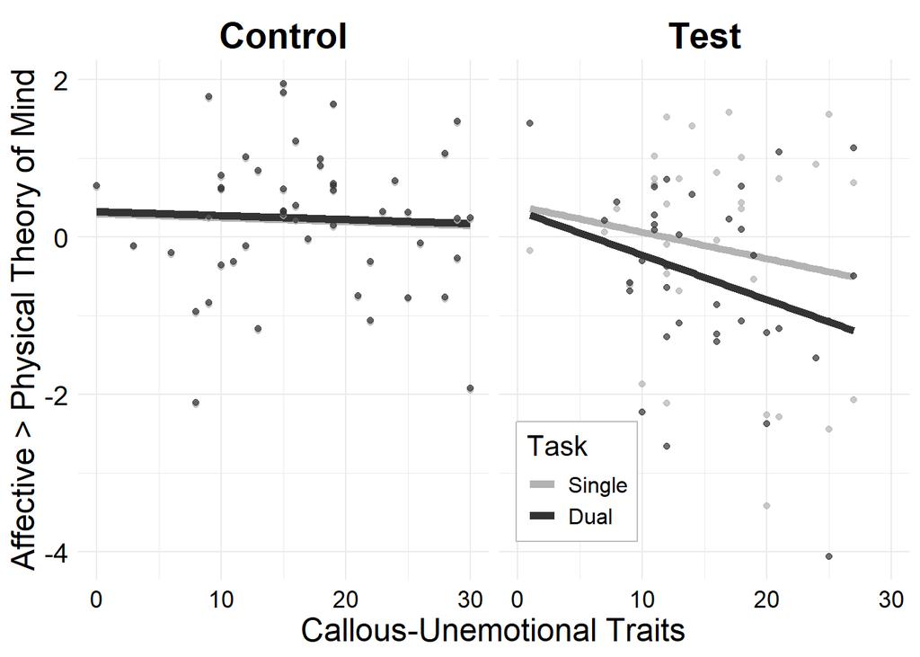

```r
  # CU______________
ggplot(
  data=dat_plot,
  aes(
    x=cu*22,                              # add denominator- rescale mean score
    y=random.intercpet.preds_cont_at_pc,
    group = factor(time_rc),
    colour = factor(time_rc)
    )
  ) +
  geom_smooth(
    method='lm',
    se=FALSE,
    size=2
    ) +
  geom_point(alpha=0.7)+
  labs(
    x="Callous-Unemotional Traits",
    y="Affective > Physical Theory of Mind"
    ) +
  scale_colour_grey(
    "Task",
    start = .7,
    end= .2
    ) +
  # ylim(10,26) +
  facet_grid(. ~ fct_relevel(
    dat_plot$hi_lo2,
    "Control",
    "Test")
    ) +
  theme_minimal() +
  theme(
    axis.text=element_text(
      size=rel(1.1)
    ),
    axis.title=element_text(
      size=rel(1.6)
    ),
    strip.text.x.top = element_text(
      colour = "black",
      face = "bold",
      size=rel(2.25)
    ),
    axis.text.x = element_text(
      colour = "black",
      face="plain",
      size=rel(1.1)
    ),
    axis.text.y = element_text(
      colour = "black",
      face="plain",
      size=rel(1.2)
    ),
    legend.title = element_text(
      size=rel(1.4)
    ),
    legend.text = element_text(
      size=rel(1.1)
    ),
    legend.position = c(0.6,0.19),
    legend.background = element_rect(
      fill="white",
      color = "grey")
    )
```

```r
ggsave(
  paste0(base_fig,"\\tom_at_pc_contrast_task_line_CU.tiff"),
  plot = last_plot(),
  device = "tiff",
  scale = 1,
  width = 5.5,
  height = 4.5,
  units = "in",
  dpi = 300
)
```

### 5.1.3 **Cognitive > Physical** ToM

#### 5.1.3.1 Contrast

```r
  ## calculating contrast
dat_long$tom_acc_ct_pc <- resid(
  lm((dat_long$tom_acc_ct - dat_long$tom_acc_pc)~ dat_long$tom_acc_pc)
  )
```

#### 5.1.3.2 Model

```r
ct_pc_mix_p <- lmer(tom_acc_ct_pc  ~
                      cu +
                      sdq_cd +
                      sex_male +
                      race_white +
                      iq +
                      careless +
                      sdq_hyperactivity +
                      sdq_internalizing +
                      time +
                      group_di +
                      order_var+
                      int_gptime +
                      int_cdcu +
                      int_cdcugp +
                      int_cdcutime +
                      int_cdcugptime +
                      int_cugp +
                      int_cugptime +
                      int_cdgp +
                      int_cdgptime +
                      (1|id),
                    data = dat_long)
```

#### 5.1.3.3 Assumption check

```
##  Convergence:      OK: Model Converged
##  Singularity:      OK: Model Not Singular
##  Heteroscedacity:  OK: Error variance appears to be homoscedastic (p = 0.731).
##  Autocorrelation:  OK: Residuals appear to be independent and not autocorrelated (p = 0.124).
##  Residual dist:    OK: Simulated residuals appear as uniformly distributed (p = 0.504).
##  Multicollinerity: OK: No Multicollinearity (All IVs VIF < 3)
##  Endogenity:       OK: IVs are exogenous (p > 0.05)
##  Random effects:   OK: Random effects indicated
##  Outliers:         OK: No outliers detected.
## - Based on the following method and threshold: cook (1).
## - For variable: (Whole model)
```

#### 5.1.3.4 Model performance

```r
(ct_pc_mix_p_st <- performance(ct_pc_mix_p))
```

| AIC | AICc | BIC | R2_conditional | R2_marginal | ICC | RMSE | Sigma |
| --- | --- | --- | --- | --- | --- | --- | --- |
| 639.5433 | 647.1049 | 711.6666 | 0.3306715 | 0.09518274 | 0.2602612 | 1.107043 | 1.317162 |

#### 5.1.3.5 Results (boostrap corrected)

```r
# summary(ct_pc_mix_p)
(ct_pc_df <- mix_boot_report(ct_pc_mix_p))
```

|  | beta.boot | se.boot | t.boot | p.satw_boot | ci.boot_low | ci.boot_hi |
| --- | --- | --- | --- | --- | --- | --- |
| (Intercept) | -1.01338 | 0.91636 | -1.114 | 0.269 | -2.78594 | 0.8078 |
| cu | 0.75779 | 0.56565 | 1.360 | 0.178 | -0.33044 | 1.8673 |
| sdq_cd | -0.26390 | 0.56808 | -0.471 | 0.639 | -1.38686 | 0.8381 |
| sex_male | -0.24227 | 0.31130 | -0.786 | 0.435 | -0.85704 | 0.3660 |
| race_white | -0.40013 | 0.32620 | -1.250 | 0.215 | -1.03491 | 0.2373 |
| iq | 0.00828 | 0.00853 | 0.972 | 0.334 | -0.00853 | 0.0249 |
| careless | -0.14007 | 0.36732 | -0.385 | 0.702 | -0.85759 | 0.5820 |
| sdq_hyperactivity | 0.08779 | 0.36655 | 0.241 | 0.810 | -0.63647 | 0.8142 |
| sdq_internalizing | -0.29000 | 0.51680 | -0.570 | 0.570 | -1.33283 | 0.6979 |
| time | 0.14015 | 0.20358 | 0.703 | 0.484 | -0.25771 | 0.5369 |

[output cut: 17 more lines]

```r
# saving results to csv
write.csv(
  ct_pc_df,
  tom_change_accuracy_cognitive_physical_contrast,
  row.names=TRUE
  )
```

#### 5.1.3.6 Figures

- Not necessary - nothing significant

### 5.1.4 **Affective > Cognitive** ToM

#### 5.1.4.1 Contrast

```r
  ## calculating contrast
dat_long$tom_acc_at_ct <- resid(
  lm((dat_long$tom_acc_at - dat_long$tom_acc_ct)~ dat_long$tom_acc_ct)
  )
```

#### 5.1.4.2 Model

```r
at_ct_mix_p <- lmer(tom_acc_at_ct  ~
                      cu +
                      sdq_cd +
                      sex_male +
                      race_white +
                      iq +
                      careless +
                      sdq_hyperactivity +
                      sdq_internalizing +
                      time +
                      group_di +
                      order_var+
                      int_gptime +
                      int_cdcu +
                      int_cdcugp +
                      int_cdcugptime +
                      int_cugp +
                      int_cugptime +
                      int_cdgp +
                      int_cdgptime +
                      (1|id),
                    data = dat_long)
```

#### 5.1.4.3 Assumption check

```
##  Convergence:      OK: Model Converged
##  Singularity:      OK: Model Not Singular
##  Heteroscedacity:  OK: Error variance appears to be homoscedastic (p = 0.744).
##  Autocorrelation:  OK: Residuals appear to be independent and not autocorrelated (p = 0.070).
##  Residual dist:    OK: Simulated residuals appear as uniformly distributed (p = 0.897).
##  Multicollinerity: OK: No Multicollinearity (All IVs VIF < 3)
##  Endogenity:       OK: IVs are exogenous (p > 0.05)
##  Random effects:   OK: Random effects indicated
##  Outliers:         OK: No outliers detected.
## - Based on the following method and threshold: cook (1).
## - For variable: (Whole model)
```

#### 5.1.4.4 Model performance

```r
(at_ct_mix_p_st <- performance(at_ct_mix_p))
```

| AIC | AICc | BIC | R2_conditional | R2_marginal | ICC | RMSE | Sigma |
| --- | --- | --- | --- | --- | --- | --- | --- |
| 674.0563 | 680.9406 | 743.0438 | 0.5503392 | 0.1359258 | 0.479604 | 1.028167 | 1.310633 |

#### 5.1.4.5 Results (boostrap corrected)

```r
# summary(at_ct_mix_p)
(at_ct_df <- mix_boot_report(at_ct_mix_p))
```

|  | beta.boot | se.boot | t.boot | p.satw_boot | ci.boot_low | ci.boot_hi |
| --- | --- | --- | --- | --- | --- | --- |
| (Intercept) | -0.5736 | 1.1749 | -0.488 | 0.6272 | -2.9209 | 1.7289 |
| cu | -0.8196 | 0.7252 | -1.141 | 0.2577 | -2.2345 | 0.6246 |
| sdq_cd | -1.1576 | 0.7366 | -1.601 | 0.1138 | -2.6151 | 0.2967 |
| sex_male | 0.0716 | 0.3995 | 0.179 | 0.8584 | -0.7202 | 0.8615 |
| race_white | 0.0519 | 0.4195 | 0.126 | 0.9002 | -0.7735 | 0.8799 |
| iq | 0.0103 | 0.0109 | 0.935 | 0.3529 | -0.0109 | 0.0322 |
| careless | -0.4791 | 0.4741 | -1.024 | 0.3093 | -1.4090 | 0.4437 |
| sdq_hyperactivity | 0.4701 | 0.4685 | 1.010 | 0.3160 | -0.4575 | 1.3933 |
| sdq_internalizing | 0.8028 | 0.6609 | 1.226 | 0.2243 | -0.4898 | 2.1130 |
| time | -0.3043 | 0.2014 | -1.528 | 0.1303 | -0.7060 | 0.0892 |

[output cut: 16 more lines]

```r
# saving results to csv
write.csv(
  at_ct_df,
  tom_change_accuracy_affective_cognitive_contrast,
  row.names=TRUE
  )
```

#### 5.1.4.6 Figures

##### 5.1.4.6.1 Organizing plot data

```r
random.intercpet.preds_cont_at_ct <- predict(at_ct_mix_p)
```

##### 5.1.4.6.2 CU and CD by Task

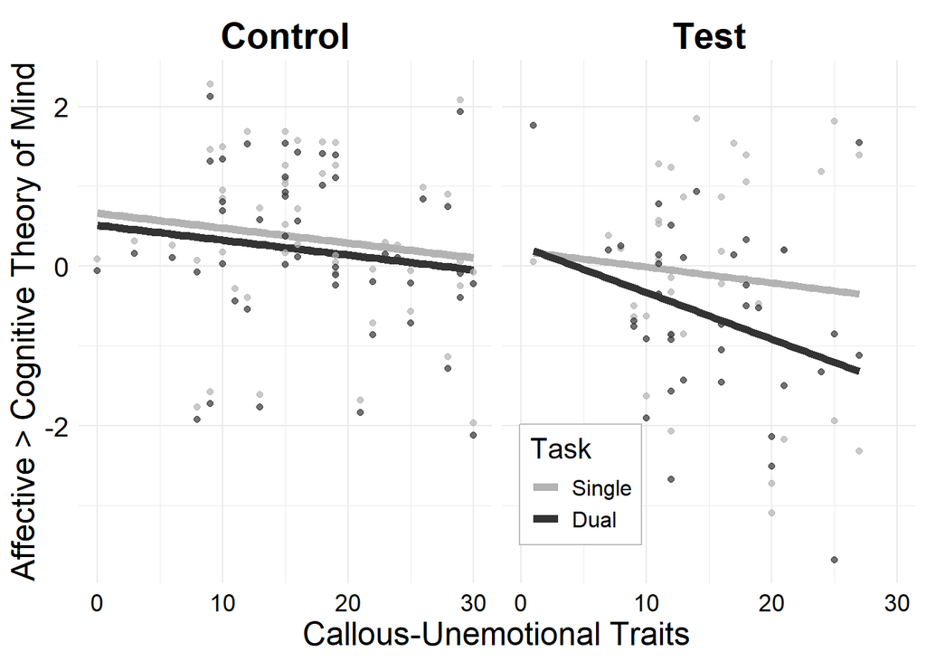

```r
  # CU______________
ggplot(
  data=dat_plot,
  aes(
    x=cu*22,                              # add denominator- rescale mean score
    y=random.intercpet.preds_cont_at_ct,
    group = factor(time_rc),
    colour = factor(time_rc)
    )
  ) +
  geom_smooth(
    method='lm',
    se=FALSE,
    size=2
    ) +
  geom_point(alpha=0.7)+
  labs(
    x="Callous-Unemotional Traits",
    y="Affective > Cognitive Theory of Mind"
    ) +
  scale_colour_grey(
    "Task",
    start = .7,
    end= .2
    ) +
  # ylim(10,26) +
  facet_grid(. ~ fct_relevel(
    dat_plot$hi_lo2,
    "Control",
    "Test")
    ) +
  theme_minimal() +
  theme(
    axis.text=element_text(
      size=rel(1.1)
    ),
    axis.title=element_text(
      size=rel(1.6)
    ),
    strip.text.x.top = element_text(
      colour = "black",
      face = "bold",
      size=rel(2.25)
    ),
    axis.text.x = element_text(
      colour = "black",
      face="plain",
      size=rel(1.1)
    ),
    axis.text.y = element_text(
      colour = "black",
      face="plain",
      size=rel(1.2)
    ),
    legend.title = element_text(
      size=rel(1.4)
    ),
    legend.text = element_text(
      size=rel(1.1)
    ),
    legend.position = c(0.6,0.19),
    legend.background = element_rect(
      fill="white",
      color = "grey")
    )
```

```r
ggsave(
  paste0(base_fig,"\\tom_at_ct_contrast_task_line_CU.tiff"),
  plot = last_plot(),
  device = "tiff",
  scale = 1,
  width = 5.5,
  height = 4.5,
  units = "in",
  dpi = 300
)
```

## 5.2 **Dual-Task ToM - Loading Effect**

- Here we model interaction terms because
  - Loading effect is still present in control participants (although smaller)
  - This needs to be accounted for by modeling test vs no test conditions
- Interpretation
  - **Higher values** = *less* *loading effect* (easier to complete trial)
  - **Lower values** = *greater* *loading effect* (greater difficulty completing trial)

### 5.2.1 **Total** ToM *Loading Effect*

#### 5.2.1.1 Model

```r
load_eff_total <- lm(
  tom_dual_task_eff_rt_total ~
    cu_total_mean +
    sdq_cd +
    sex_male +
    race_white +
    iq +
    careless +
    sdq_hyperactivity +
    sdq_internalizing +
    group_di +
    int_cucd +
    int_cucdtest +
    int_cutest +
    int_cdtest,
  data = dat
)

total_load_eff <- lmer(
  tom_dual_task_eff_rt_total ~
    cu_total_mean +
    sdq_cd +
    sex_male +
    race_white +
    iq +
    careless +
    sdq_hyperactivity +
    sdq_internalizing +
    group_di +
    group_di +
    int_cucd +
    int_cucdtest +
    int_cutest +
    int_cdtest +
    (1|order_var),
  data = dat
)

anova(total_load_eff,load_eff_total)
```

|  | npar | AIC | BIC | logLik | deviance | Chisq | Df | Pr(>Chisq) |
| --- | --- | --- | --- | --- | --- | --- | --- | --- |
| load_eff_total | 15 | 66.32663 | 102.96640 | -18.16332 | 36.32663 | NA | NA | NA |
| total_load_eff | 16 | 58.37423 | 97.45665 | -13.18712 | 26.37423 | 9.952398 | 1 | 0.0016064 |

```r
compare_performance(load_eff_total, total_load_eff)
```

| Name | Model | AIC | AIC_wt | AICc | AICc_wt | BIC | BIC_wt | RMSE | Sigma | R2 | R2_adjusted | R2_conditional | R2_marginal | ICC |
| --- | --- | --- | --- | --- | --- | --- | --- | --- | --- | --- | --- | --- | --- | --- |
| load_eff_total | lm | 66.32663 | 0.0207771 | 73.28315 | 0.03451725 | 102.96640 | 0.06713328 | 0.2996163 | 0.3278278 | 0.2828977 | 0.1515973 | NA | NA | NA |
| total_load_eff | lmerModLmerTest | 58.62081 | 0.9792229 | 66.62081 | 0.96548275 | 97.70323 | 0.93286672 | 0.2715519 | 0.2990959 | NA | NA | 0.4226235 | 0.1778921 | 0.2976877 |

- clearly the random effect improves estimation - we we will run random eff
  - better model fit and error
  - more accurate R2

#### 5.2.1.2 Assumptions

```r
model = total_load_eff
if (check_singularity(model)==FALSE){
  cat(" Singularity:     ", crayon::green("OK: Model Not Singular"))
} else if (check_singularity(model)==TRUE){
  cat(" Singularity:     ", crayon::red("Warning: Model Singular"))
}
```

```
##  Singularity:      OK: Model Not Singular
```

```r
if (check_convergence(model)[1]==TRUE){
  cat("\n Convergence:     ", crayon::green("OK: Model Converged"))
} else if (check_convergence(model)[1]==FALSE){
  cat("\n Convergence:     ", crayon::red("Warning: Model did not converge"))
}
```

```
##
##  Convergence:      OK: Model Converged
```

```r
if (check_autocorrelation(model)>0.05){
  cat("\n Autocorrelation: ", crayon::green("OK: Residuals appear to be independent and not autocorrelated"))
} else if (check_autocorrelation(model)<0.05){
  cat("\n Autocorrelation: ", crayon::red("Warning: Residuals autocorrelated"))
}
```

```
##
##  Autocorrelation:  OK: Residuals appear to be independent and not autocorrelated
```

```r
if (all(check_collinearity(model)$VIF) < 3){
  cat("\n Multicolinearity:", crayon::green("OK: No Multicolinearity"))
} else if (any(check_collinearity(model)$VIF) > 3) {
  cat("\n Multicolinearity:", crayon::red("Warning: Multicolinearity"))
}
```

```
##
##  Multicolinearity: OK: No Multicolinearity
```

```r
if (all(check_outliers(model)) ==FALSE){
  cat("\n Outliers:        ", crayon::green("OK: No outliers"))
} else if (all(check_outliers(model)) ==TRUE) {
  cat("\n Outliers:        ", crayon::red("Warning: Outliers detected"))
}
```

```
##
##  Outliers:         OK: No outliers
```

#### 5.2.1.3 Results (boostrap corrected)

```r
df<-as.data.frame(as.data.frame(summary(total_load_eff)$coefficients),digits=3)
df_ci<-lme4::confint.merMod(total_load_eff)
total_load_eff_df<-cbind(df,as.data.frame(df_ci)[3:16,])
re <- (rbind(c(rowMeans(df_ci[c(1,2),]),NA,NA,NA,NA,NA),
      c(rowMeans(var(df_ci[c(1,2),])),NA,NA,NA,NA,NA)))
colnames(re)<-colnames(total_load_eff_df)
rownames(re) <- c("residual", "intercept")
total_load_eff_df<-rbind(total_load_eff_df,re)
r2<-t(as.data.frame(c(performance(total_load_eff)$R2_marginal,NA,NA,NA,NA,NA,NA)))
colnames(r2)<-colnames(total_load_eff_df)
rownames(r2) <- c("R2")
(total_load_eff_df<-rbind(total_load_eff_df,r2))
```

|  | Estimate | Std. Error | df | t value | Pr(>\|t\|) | 2.5 % | 97.5 % |
| --- | --- | --- | --- | --- | --- | --- | --- |
| (Intercept) | 0.0572481212 | 0.259227115 | 10.18418 | 0.220841563 | 0.82958048 | -0.399281268 | 0.511265699 |
| cu_total_mean | 0.0003560330 | 0.138573781 | 70.40124 | 0.002569266 | 0.99795729 | -0.246837294 | 0.260429246 |
| sdq_cd | 0.0583600505 | 0.027916906 | 70.10912 | 2.090491345 | 0.04020090 | 0.006805288 | 0.108629376 |
| sex_male | 0.1346201493 | 0.076673594 | 70.09957 | 1.755756357 | 0.08349825 | -0.003510667 | 0.276118341 |
| race_white | -0.0937959710 | 0.079656600 | 70.00386 | -1.177504071 | 0.24298218 | -0.239236969 | 0.050965836 |
| iq | -0.0009552011 | 0.002118110 | 70.11510 | -0.450968617 | 0.65340379 | -0.004868387 | 0.002857728 |
| careless | -0.1623972109 | 0.090483745 | 70.03308 | -1.794766684 | 0.07700606 | -0.326139203 | 0.003612830 |
| sdq_hyperactivity | -0.0099725268 | 0.017965700 | 70.26406 | -0.555087015 | 0.58059805 | -0.043456679 | 0.022191638 |
| sdq_internalizing | -0.0037215296 | 0.012641222 | 70.00272 | -0.294396354 | 0.76932628 | -0.026793538 | 0.019260060 |
| group_di | -0.1377676772 | 0.071609757 | 70.00041 | -1.923867396 | 0.05843788 | -0.268305319 | -0.007428212 |

[output cut: 7 more lines]

```r
# saving results to csv
write.csv(
  total_load_eff_df,
  total_load_eff_file,
  row.names=TRUE
  )
```

#### 5.2.1.4 Figures

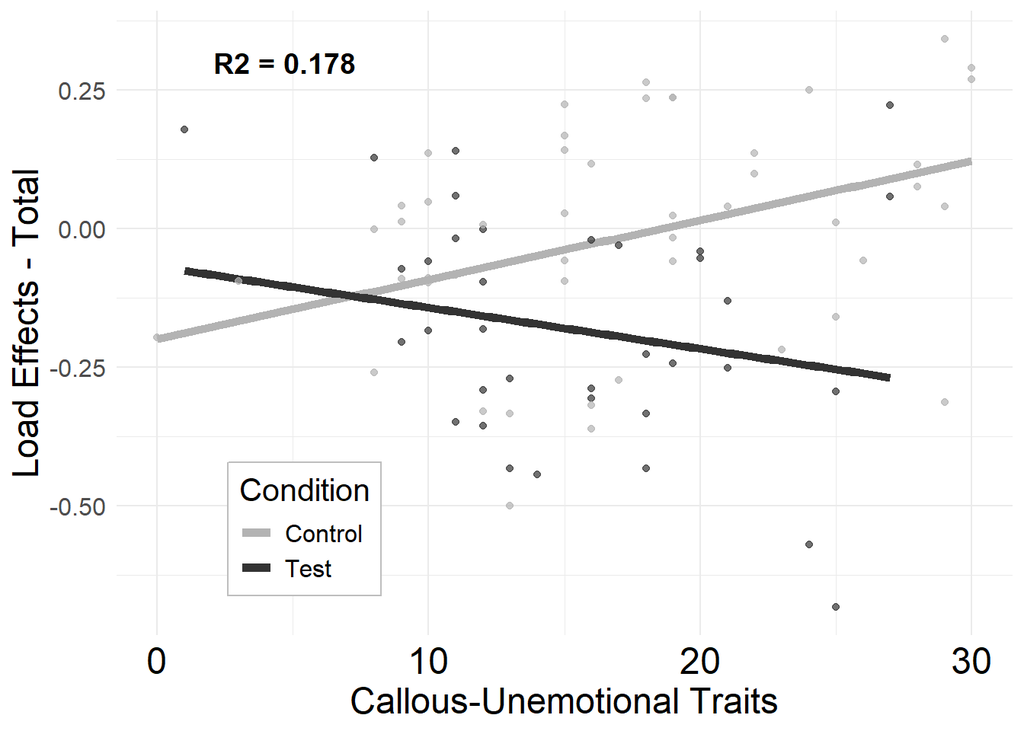

```r
total_load_eff.pred <- predict(total_load_eff)

ggplot(
  data=dat,
  aes(
    x=cu_total_sum,
    y=total_load_eff.pred,
    group = factor(group_di),
    colour = factor(group_di)
  )
) +
  geom_smooth(
    method='lm',
    se=FALSE,
    size=2
  ) +
  geom_point(alpha=0.7)+
  labs(
    x="Callous-Unemotional Traits",
    y="Load Effects - Total"
  ) +
  scale_colour_grey(
    "Condition",
    start = .7,
    end= .2,
    labels = c("Control", "Test")
  ) +
  theme_minimal() +       # setting theme and text parameters
  theme(
    axis.text=element_text(
      size=rel(1.1)
    ),
    axis.title=element_text(
      size=rel(1.6)
    ),
    strip.text.x.top = element_text(
      colour = "black",
      face = "bold",
      size=rel(2.5)
    ),
    axis.text.x = element_text(
      colour = "black",
      face="plain",
      size=rel(1.5)
    ),
    legend.title = element_text(
      size=rel(1.4)
    ),
    legend.text = element_text(
      size=rel(1.1)
    ),
    legend.position = c(0.21,0.17),
    legend.background = element_rect(
      fill="white",
      color = "grey")
  ) + annotate("text",
               x=4.7,
               y=0.3,
               label = paste("R2", "=", round(performance(total_load_eff)$R2_marginal,3)),
               fontface="bold",
               size=5
               )
```

```r
ggsave(
  paste0(base_fig,"\\load_effect_total_CU.tiff"),
  plot = last_plot(),
  device = "tiff",
  scale = 1,
  width = 4,
  height = 4,
  units = "in",
  dpi = 300
)
```

### 5.2.2 **Affective** ToM *Loading Effect*

#### 5.2.2.1 Model

```r
load_eff_at <- lm(
  tom_dual_task_eff_rt_at ~
    cu_total_mean +
    sdq_cd +
    sex_male +
    race_white +
    iq +
    careless +
    sdq_hyperactivity +
    sdq_internalizing +
    group_di +
    int_cucd +
    int_cucdtest +
    int_cutest +
    int_cdtest,
  data = dat
)

at_load_eff <- lmer(
  tom_dual_task_eff_rt_at ~
    cu_total_mean +
    sdq_cd +
    sex_male +
    race_white +
    iq +
    careless +
    sdq_hyperactivity +
    sdq_internalizing +
    group_di +
    int_cucd +
    int_cucdtest +
    int_cutest +
    int_cdtest +
    (1|order_var),
  data = dat
)

anova(at_load_eff,load_eff_at)
```

|  | npar | AIC | BIC | logLik | deviance | Chisq | Df | Pr(>Chisq) |
| --- | --- | --- | --- | --- | --- | --- | --- | --- |
| load_eff_at | 15 | 67.28881 | 103.9286 | -18.64441 | 37.28881 | NA | NA | NA |
| at_load_eff | 16 | 67.40567 | 106.4881 | -17.70283 | 35.40567 | 1.883143 | 1 | 0.1699774 |

```r
compare_performance(at_load_eff,load_eff_at)[c("RMSE", "Sigma")]
```

| RMSE | Sigma |
| --- | --- |
| 0.2900654 | 0.3192384 |
| 0.3013169 | 0.3296885 |

- random effect model error is better - so running random eff

#### 5.2.2.2 Assumptions

```r
model = at_load_eff
if (check_singularity(model)==FALSE){
  cat(" Singularity:     ", crayon::green("OK: Model Not Singular"))
} else if (check_singularity(model)==TRUE){
  cat(" Singularity:     ", crayon::red("Warning: Model Singular"))
}
```

```
##  Singularity:      OK: Model Not Singular
```

```r
if (check_convergence(model)[1]==TRUE){
  cat("\n Convergence:     ", crayon::green("OK: Model Converged"))
} else if (check_convergence(model)[1]==FALSE){
  cat("\n Convergence:     ", crayon::red("Warning: Model did not converge"))
}
```

```
##
##  Convergence:      OK: Model Converged
```

```r
if (check_autocorrelation(model)>0.05){
  cat("\n Autocorrelation: ", crayon::green("OK: Residuals appear to be independent and not autocorrelated"))
} else if (check_autocorrelation(model)<0.05){
  cat("\n Autocorrelation: ", crayon::red("Warning: Residuals autocorrelated"))
}
```

```
##
##  Autocorrelation:  OK: Residuals appear to be independent and not autocorrelated
```

```r
if (all(check_collinearity(model)$VIF) < 3){
  cat("\n Multicolinearity:", crayon::green("OK: No Multicolinearity"))
} else if (any(check_collinearity(model)$VIF) > 3) {
  cat("\n Multicolinearity:", crayon::red("Warning: Multicolinearity"))
}
```

```
##
##  Multicolinearity: OK: No Multicolinearity
```

```r
if (all(check_outliers(model)) ==FALSE){
  cat("\n Outliers:        ", crayon::green("OK: No outliers"))
} else if (all(check_outliers(model)) ==TRUE) {
  cat("\n Outliers:        ", crayon::red("Warning: Outliers detected"))
}
```

```
##
##  Outliers:         OK: No outliers
```

#### 5.2.2.3 Results (boostrap corrected)

```r
df<-as.data.frame(as.data.frame(summary(at_load_eff)$coefficients),digits=3)
df_ci<-lme4::confint.merMod(at_load_eff)
at_load_eff_df<-cbind(df,as.data.frame(df_ci)[3:16,])
re <- (rbind(c(rowMeans(df_ci[c(1,2),]),NA,NA,NA,NA,NA),
      c(rowMeans(var(df_ci[c(1,2),])),NA,NA,NA,NA,NA)))
colnames(re)<-colnames(at_load_eff_df)
rownames(re) <- c("residual", "intercept")
at_load_eff_df<-rbind(at_load_eff_df,re)
r2<-t(as.data.frame(c(performance(at_load_eff)$R2_marginal,NA,NA,NA,NA,NA,NA)))
colnames(r2)<-colnames(at_load_eff_df)
rownames(r2) <- c("R2")
(at_load_eff_df<-rbind(at_load_eff_df,r2))
```

|  | Estimate | Std. Error | df | t value | Pr(>\|t\|) | 2.5 % | 97.5 % |
| --- | --- | --- | --- | --- | --- | --- | --- |
| (Intercept) | -0.1658782010 | 0.249140451 | 33.17634 | -0.6658020 | 0.51014080 | -0.603397118 | 0.280375135 |
| cu_total_mean | 0.0673289580 | 0.147507629 | 70.84892 | 0.4564439 | 0.64946703 | -0.192684634 | 0.352775528 |
| sdq_cd | 0.0654731800 | 0.029776998 | 70.27833 | 2.1987838 | 0.03118686 | 0.009761082 | 0.118688159 |
| sex_male | 0.1812156145 | 0.081787251 | 70.25508 | 2.2156951 | 0.02995434 | 0.034939872 | 0.334029703 |
| race_white | -0.0230192165 | 0.085019081 | 70.01030 | -0.2707535 | 0.78737725 | -0.178646827 | 0.131295905 |
| iq | -0.0002870145 | 0.002259153 | 70.29275 | -0.1270452 | 0.89926738 | -0.004517353 | 0.003748504 |
| careless | -0.1913243534 | 0.096558104 | 70.08723 | -1.9814427 | 0.05146547 | -0.365298516 | -0.012961050 |
| sdq_hyperactivity | -0.0077008137 | 0.019143108 | 70.61894 | -0.4022760 | 0.68869593 | -0.044198849 | 0.026211612 |
| sdq_internalizing | -0.0100670285 | 0.013492321 | 70.00725 | -0.7461302 | 0.45808694 | -0.034747075 | 0.014438301 |
| group_di | -0.0500419816 | 0.076432103 | 70.00109 | -0.6547247 | 0.51479065 | -0.189537374 | 0.089070511 |

[output cut: 7 more lines]

```r
# saving results to csv
write.csv(
  at_load_eff_df,
  at_load_eff_file,
  row.names=TRUE
  )
```

#### 5.2.2.4 Figures

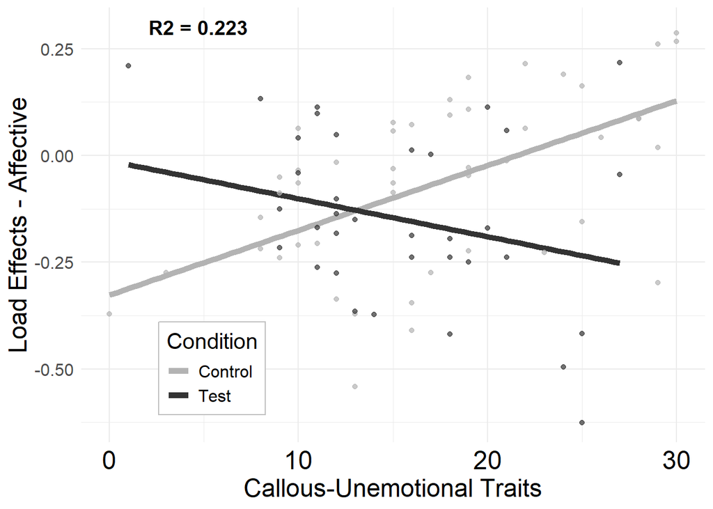

```r
at_load_eff.pred <- predict(at_load_eff)

ggplot(
  data=dat,
  aes(
    x=cu_total_sum,
    y=at_load_eff.pred,
    group = factor(group_di),
    colour = factor(group_di)
  )
) +
  geom_smooth(
    method='lm',
    se=FALSE,
    size=2
  ) +
  geom_point(alpha=0.7)+
  labs(
    x="Callous-Unemotional Traits",
    y="Load Effects - Affective"
  ) +
  scale_colour_grey(
    "Condition",
    start = .7,
    end= .2,
    labels = c("Control", "Test")
  ) +
  theme_minimal() +       # setting theme and text parameters
  theme(
    axis.text=element_text(
      size=rel(1.1)
    ),
    axis.title=element_text(
      size=rel(1.6)
    ),
    strip.text.x.top = element_text(
      colour = "black",
      face = "bold",
      size=rel(2.5)
    ),
    axis.text.x = element_text(
      colour = "black",
      face="plain",
      size=rel(1.5)
    ),
    legend.title = element_text(
      size=rel(1.4)
    ),
    legend.text = element_text(
      size=rel(1.1)
    ),
    legend.position = c(0.21,0.17),
    legend.background = element_rect(
      fill="white",
      color = "grey")
  ) + annotate("text",
               x=4.7,
               y=0.3,
               label = paste("R2", "=", round(performance(at_load_eff)$R2_marginal,3)),
               fontface="bold",
               size=5
               )
```

```r
ggsave(
  paste0(base_fig,"\\load_effect_affective_CU.tiff"),
  plot = last_plot(),
  device = "tiff",
  scale = 1,
  width = 4,
  height = 4,
  units = "in",
  dpi = 300
)
```

### 5.2.3 **Cognitive** ToM *Loading Effect*

#### 5.2.3.1 Model

```r
load_eff_ct <- lm(
  tom_dual_task_eff_rt_ct ~
    cu_total_mean +
    sdq_cd +
    sex_male +
    race_white +
    iq +
    careless +
    sdq_hyperactivity +
    sdq_internalizing +
    group_di +
    int_cucd +
    int_cucdtest +
    int_cutest +
    int_cdtest,
  data = dat
)

ct_load_eff <- lmer(
  tom_dual_task_eff_rt_ct ~
    cu_total_mean +
    sdq_cd +
    sex_male +
    race_white +
    iq +
    careless +
    sdq_hyperactivity +
    sdq_internalizing +
    group_di +
    int_cucd +
    int_cucdtest +
    int_cutest +
    int_cdtest +
    (1|order_var),
  data = dat
)

anova(ct_load_eff,load_eff_ct)
```

|  | npar | AIC | BIC | logLik | deviance | Chisq | Df | Pr(>Chisq) |
| --- | --- | --- | --- | --- | --- | --- | --- | --- |
| load_eff_ct | 15 | 90.74335 | 127.3831 | -30.37167 | 60.74335 | NA | NA | NA |
| ct_load_eff | 16 | 81.87354 | 120.9560 | -24.93677 | 49.87354 | 10.8698 | 1 | 0.0009774499 |

- random effects improves model estimation

#### 5.2.3.2 Assumptions

```r
model = ct_load_eff
if (check_singularity(model)==FALSE){
  cat(" Singularity:     ", crayon::green("OK: Model Not Singular"))
} else if (check_singularity(model)==TRUE){
  cat(" Singularity:     ", crayon::red("Warning: Model Singular"))
}
```

```
##  Singularity:      OK: Model Not Singular
```

```r
if (check_convergence(model)[1]==TRUE){
  cat("\n Convergence:     ", crayon::green("OK: Model Converged"))
} else if (check_convergence(model)[1]==FALSE){
  cat("\n Convergence:     ", crayon::red("Warning: Model did not converge"))
}
```

```
##
##  Convergence:      OK: Model Converged
```

```r
if (check_autocorrelation(model)>0.05){
  cat("\n Autocorrelation: ", crayon::green("OK: Residuals appear to be independent and not autocorrelated"))
} else if (check_autocorrelation(model)<0.05){
  cat("\n Autocorrelation: ", crayon::red("Warning: Residuals autocorrelated"))
}
```

```
##
##  Autocorrelation:  OK: Residuals appear to be independent and not autocorrelated
```

```r
if (all(check_collinearity(model)$VIF) < 3){
  cat("\n Multicolinearity:", crayon::green("OK: No Multicolinearity"))
} else if (any(check_collinearity(model)$VIF) > 3) {
  cat("\n Multicolinearity:", crayon::red("Warning: Multicolinearity"))
}
```

```
##
##  Multicolinearity: OK: No Multicolinearity
```

```r
if (all(check_outliers(model)) ==FALSE){
  cat("\n Outliers:        ", crayon::green("OK: No outliers"))
} else if (all(check_outliers(model)) ==TRUE) {
  cat("\n Outliers:        ", crayon::red("Warning: Outliers detected"))
}
```

```
##
##  Outliers:         OK: No outliers
```

#### 5.2.3.3 Results (boostrap corrected)

```r
df<-as.data.frame(as.data.frame(summary(ct_load_eff)$coefficients),digits=3)
df_ci<-lme4::confint.merMod(ct_load_eff)
ct_load_eff_df<-cbind(df,as.data.frame(df_ci)[3:16,])
re <- (rbind(c(rowMeans(df_ci[c(1,2),]),NA,NA,NA,NA,NA),
      c(rowMeans(var(df_ci[c(1,2),])),NA,NA,NA,NA,NA)))
colnames(re)<-colnames(ct_load_eff_df)
rownames(re) <- c("residual", "intercept")
ct_load_eff_df<-rbind(ct_load_eff_df,re)
r2<-t(as.data.frame(c(performance(ct_load_eff)$R2_marginal,NA,NA,NA,NA,NA,NA)))
colnames(r2)<-colnames(ct_load_eff_df)
rownames(r2) <- c("R2")
(ct_load_eff_df<-rbind(ct_load_eff_df,r2))
```

|  | Estimate | Std. Error | df | t value | Pr(>\|t\|) | 2.5 % | 97.5 % |
| --- | --- | --- | --- | --- | --- | --- | --- |
| (Intercept) | 3.526045e-02 | 0.300526328 | 9.364326 | 0.11732898 | 0.90907748 | -0.496525975 | 0.563947493 |
| cu_total_mean | -3.993176e-02 | 0.159003893 | 70.378069 | -0.25113700 | 0.80244000 | -0.323744336 | 0.258105088 |
| sdq_cd | 5.557538e-02 | 0.032030212 | 70.102196 | 1.73509241 | 0.08711896 | -0.003542287 | 0.113272704 |
| sex_male | 1.393128e-01 | 0.087970555 | 70.093231 | 1.58363023 | 0.11777978 | -0.019226053 | 0.301572542 |
| race_white | -1.317551e-01 | 0.091390986 | 70.003609 | -1.44166442 | 0.15385584 | -0.298603178 | 0.034342318 |
| iq | 2.721068e-06 | 0.002430198 | 70.107806 | 0.00111969 | 0.99910980 | -0.004484444 | 0.004379109 |
| careless | -2.126163e-01 | 0.103813813 | 70.030941 | -2.04805360 | 0.04430582 | -0.400520158 | -0.022205970 |
| sdq_hyperactivity | -2.917504e-02 | 0.020613606 | 70.248028 | -1.41532903 | 0.16139012 | -0.067557520 | 0.007749315 |
| sdq_internalizing | 6.428735e-03 | 0.014503424 | 70.002540 | 0.44325640 | 0.65894718 | -0.020039556 | 0.032797103 |
| group_di | -1.839580e-01 | 0.082158679 | 70.000381 | -2.23905762 | 0.02833241 | -0.333718054 | -0.034416992 |

[output cut: 7 more lines]

```r
# saving results to csv
write.csv(
  ct_load_eff_df,
  ct_load_eff_file,
  row.names=TRUE
  )
```

#### 5.2.3.4 Figures

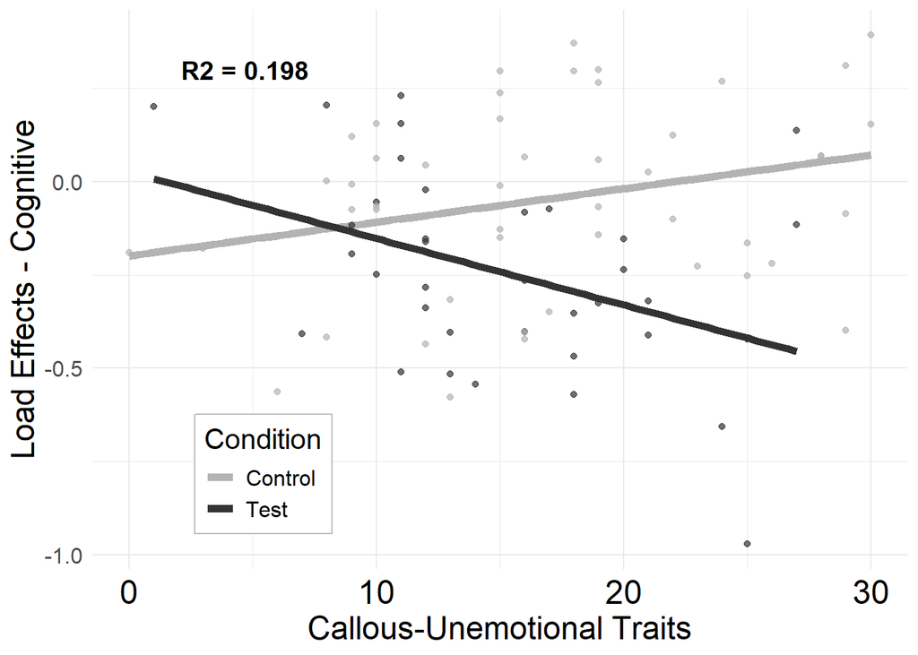

```r
ct_load_eff.pred <- predict(ct_load_eff)

ggplot(
  data=dat,
  aes(
    x=cu_total_sum,
    y=ct_load_eff.pred,
    group = factor(group_di),
    colour = factor(group_di)
  )
) +
  geom_smooth(
    method='lm',
    se=FALSE,
    size=2
  ) +
  geom_point(alpha=0.7)+
  labs(
    x="Callous-Unemotional Traits",
    y="Load Effects - Cognitive"
  ) +
  scale_colour_grey(
    "Condition",
    start = .7,
    end= .2,
    labels = c("Control", "Test")
  ) +
  theme_minimal() +       # setting theme and text parameters
  theme(
    axis.text=element_text(
      size=rel(1.1)
    ),
    axis.title=element_text(
      size=rel(1.6)
    ),
    strip.text.x.top = element_text(
      colour = "black",
      face = "bold",
      size=rel(2.5)
    ),
    axis.text.x = element_text(
      colour = "black",
      face="plain",
      size=rel(1.5)
    ),
    legend.title = element_text(
      size=rel(1.4)
    ),
    legend.text = element_text(
      size=rel(1.1)
    ),
    legend.position = c(0.21,0.17),
    legend.background = element_rect(
      fill="white",
      color = "grey")
  ) + annotate("text",
               x=4.7,
               y=0.3,
               label = paste("R2", "=", round(performance(ct_load_eff)$R2_marginal,3)),
               fontface="bold",
               size=5
               )
```

```r
ggsave(
  paste0(base_fig,"\\load_effect_cognitive_CU.tiff"),
  plot = last_plot(),
  device = "tiff",
  scale = 1,
  width = 4,
  height = 4,
  units = "in",
  dpi = 300
)
```

### 5.2.4 **Physical** ToM *Loading Effect*

#### 5.2.4.1 Model

```r
load_eff_pc <- lm(
  tom_dual_task_eff_rt_pc ~
    cu_total_mean +
    sdq_cd +
    sex_male +
    race_white +
    iq +
    careless +
    sdq_hyperactivity +
    sdq_internalizing +
    group_di +
    int_cucd +
    int_cucdtest +
    int_cutest +
    int_cdtest,
  data = dat
)

pc_load_eff <- lmer(
  tom_dual_task_eff_rt_pc ~
    cu_total_mean +
    sdq_cd +
    sex_male +
    race_white +
    iq +
    careless +
    sdq_hyperactivity +
    sdq_internalizing +
    group_di +
    int_cucd +
    int_cucdtest +
    int_cutest +
    int_cdtest +
    (1|order_var),
  data = dat
)

anova(pc_load_eff,load_eff_pc)
```

|  | npar | AIC | BIC | logLik | deviance | Chisq | Df | Pr(>Chisq) |
| --- | --- | --- | --- | --- | --- | --- | --- | --- |
| load_eff_pc | 15 | 105.69746 | 142.3372 | -37.84873 | 75.69746 | NA | NA | NA |
| pc_load_eff | 16 | 96.63392 | 135.7163 | -32.31696 | 64.63392 | 11.06353 | 1 | 0.0008804215 |

- random effects improves estimation

#### 5.2.4.2 Assumptions

```r
model = pc_load_eff
if (check_singularity(model)==FALSE){
  cat(" Singularity:     ", crayon::green("OK: Model Not Singular"))
} else if (check_singularity(model)==TRUE){
  cat(" Singularity:     ", crayon::red("Warning: Model Singular"))
}
```

```
##  Singularity:      OK: Model Not Singular
```

```r
if (check_convergence(model)[1]==TRUE){
  cat("\n Convergence:     ", crayon::green("OK: Model Converged"))
} else if (check_convergence(model)[1]==FALSE){
  cat("\n Convergence:     ", crayon::red("Warning: Model did not converge"))
}
```

```
##
##  Convergence:      OK: Model Converged
```

```r
if (check_autocorrelation(model)>0.05){
  cat("\n Autocorrelation: ", crayon::green("OK: Residuals appear to be independent and not autocorrelated"))
} else if (check_autocorrelation(model)<0.05){
  cat("\n Autocorrelation: ", crayon::red("Warning: Residuals autocorrelated"))
}
```

```
##
##  Autocorrelation:  OK: Residuals appear to be independent and not autocorrelated
```

```r
if (all(check_collinearity(model)$VIF) < 3){
  cat("\n Multicolinearity:", crayon::green("OK: No Multicolinearity"))
} else if (any(check_collinearity(model)$VIF) > 3) {
  cat("\n Multicolinearity:", crayon::red("Warning: Multicolinearity"))
}
```

```
##
##  Multicolinearity: OK: No Multicolinearity
```

```r
if (all(check_outliers(model)) ==FALSE){
  cat("\n Outliers:        ", crayon::green("OK: No outliers"))
} else if (all(check_outliers(model)) ==TRUE) {
  cat("\n Outliers:        ", crayon::red("Warning: Outliers detected"))
}
```

```
##
##  Outliers:         OK: No outliers
```

#### 5.2.4.3 Results (boostrap corrected)

```r
df<-as.data.frame(as.data.frame(summary(pc_load_eff)$coefficients),digits=3)
df_ci<-lme4::confint.merMod(pc_load_eff)
pc_load_eff_df<-cbind(df,as.data.frame(df_ci)[3:16,])
re <- (rbind(c(rowMeans(df_ci[c(1,2),]),NA,NA,NA,NA,NA),
      c(rowMeans(var(df_ci[c(1,2),])),NA,NA,NA,NA,NA)))
colnames(re)<-colnames(pc_load_eff_df)
rownames(re) <- c("residual", "intercept")
pc_load_eff_df<-rbind(pc_load_eff_df,re)
r2<-t(as.data.frame(c(performance(pc_load_eff)$R2_marginal,NA,NA,NA,NA,NA,NA)))
colnames(r2)<-colnames(pc_load_eff_df)
rownames(r2) <- c("R2")
(pc_load_eff_df<-rbind(pc_load_eff_df,r2))
```

|  | Estimate | Std. Error | df | t value | Pr(>\|t\|) | 2.5 % | 97.5 % |
| --- | --- | --- | --- | --- | --- | --- | --- |
| (Intercept) | 0.349701688 | 0.328446275 | 9.206729 | 1.0647150 | 0.31413070 | -0.23209534 | 0.928078801 |
| cu_total_mean | -0.019244898 | 0.173401597 | 70.373497 | -0.1109845 | 0.91194452 | -0.32879465 | 0.305697642 |
| sdq_cd | 0.046115141 | 0.034929992 | 70.100843 | 1.3202162 | 0.19105747 | -0.01834746 | 0.109040568 |
| sex_male | 0.082148455 | 0.095934717 | 70.091993 | 0.8562954 | 0.39475243 | -0.09075545 | 0.259079267 |
| race_white | -0.138036167 | 0.099664363 | 70.003562 | -1.3850103 | 0.17044739 | -0.31998461 | 0.043099911 |
| iq | -0.003418038 | 0.002650211 | 70.106380 | -1.2897229 | 0.20138537 | -0.00831088 | 0.001354915 |
| careless | -0.097351377 | 0.113211946 | 70.030525 | -0.8599038 | 0.39277632 | -0.30227453 | 0.110284383 |
| sdq_hyperactivity | 0.005808576 | 0.022479985 | 70.244879 | 0.2583888 | 0.79686247 | -0.03604120 | 0.046080358 |
| sdq_internalizing | -0.005036743 | 0.015816378 | 70.002508 | -0.3184511 | 0.75109096 | -0.03390060 | 0.023718967 |
| group_di | -0.173760006 | 0.089596266 | 70.000377 | -1.9393666 | 0.05648768 | -0.33707583 | -0.010681215 |

[output cut: 7 more lines]

```r
# saving results to csv
write.csv(
  pc_load_eff_df,
  pc_load_eff_file,
  row.names=TRUE
  )
```

#### 5.2.4.4 Figures

- None needed - not sig

## 5.3 Deliquency Association

### 5.3.1 Metrics

#### 5.3.1.1 Change score

- we derive a change score from the repeated measures affective ToM model
- we take the predicted intercepts for each individual for each timepoint
- and subtract them

```r
diff_at <- (
  random.intercpet.preds_accuracy_at[86:170] -
    random.intercpet.preds_accuracy_at[0:85]
  )
```

#### 5.3.1.2 Interactions

- here we derive interactions with the change in affective ToM with CU and CD

```r
dat$int_chgp <- resid(lm(I(group_di*diff_at)~ group_di + diff_at, data= dat))
dat$int_chgpcucd <- resid(lm(I(int_cucd*diff_at)~ int_cucd + diff_at, data= dat))
dat$int_chgpcu <- resid(lm(I(int_cutest*diff_at)~ int_cutest + diff_at, data= dat))
dat$int_chgpcd <- resid(lm(I(int_cdtest*diff_at)~ int_cdtest + diff_at, data= dat))
```

#### 5.3.1.3 log of deliquency

- log transforming the delinquency scale (as it is numeric frequency variable)
  - we add a small number so we are not inflating the transformation with 0’s
  - this also ensures the log runs correctly
- we use a natural log because it is more interpret able
  - interpret as percent difference

```r
dat$delq_total_nlog <- log1p(dat$delq_total_sum+0.1)
```

### 5.3.2 Model

```r
delq_m <- lmer(
  delq_total_nlog ~
    cu_total_sum +
    sdq_cd +
    diff_at +
    group_di +
    int_chgp +
    int_cucd +
    int_cutest +
    int_cdtest +
    int_chgpcucd +
    int_chgpcu +
    int_chgpcd +
    order_var +
    sex_male +
    iq +
    careless +
    race_white +
    sdq_hyperactivity +
    sdq_internalizing +
    (1|order_var),
  control = control,
  data = dat
  )
```

#### 5.3.2.1 Assumptions

```r
model = delq_m
if (check_singularity(pc_load_eff)==FALSE){
  cat(" Singularity:     ", crayon::green("OK: Model Not Singular"))
} else if (check_singularity(pc_load_eff)==TRUE){
  cat(" Singularity:     ", crayon::red("Warning: Model Singular"))
}
```

```
##  Singularity:      OK: Model Not Singular
```

```r
if (check_convergence(model)[1]==TRUE){
  cat("\n Convergence:     ", crayon::green("OK: Model Converged"))
} else if (check_convergence(model)[1]==FALSE){
  cat("\n Convergence:     ", crayon::red("Warning: Model did not converge"))
}
```

```
##
##  Convergence:      OK: Model Converged
```

```r
if (check_autocorrelation(model)>0.05){
  cat("\n Autocorrelation: ", crayon::green("OK: Residuals appear to be independent and not autocorrelated"))
} else if (check_autocorrelation(model)<0.05){
  cat("\n Autocorrelation: ", crayon::red("Warning: Residuals autocorrelated"))
}
```

```
##
##  Autocorrelation:  OK: Residuals appear to be independent and not autocorrelated
```

```r
if (all(check_collinearity(model)$VIF) < 3){
  cat("\n Multicolinearity:", crayon::green("OK: No Multicolinearity"))
} else if (any(check_collinearity(model)$VIF) > 3) {
  cat("\n Multicolinearity:", crayon::red("Warning: Multicolinearity"))
}
```

```
##
##  Multicolinearity: OK: No Multicolinearity
```

#### 5.3.2.2 Results (boostrap corrected)

```r
df<-as.data.frame(as.data.frame(summary(delq_m)$coefficients),digits=3)
df_ci<-lme4::confint.merMod(delq_m)
delq_m_df<-cbind(df,as.data.frame(df_ci)[3:21,])
re <- (rbind(c(rowMeans(df_ci[c(1,2),]),NA,NA,NA,NA,NA),
      c(rowMeans(var(df_ci[c(1,2),])),NA,NA,NA,NA,NA)))
colnames(re)<-colnames(delq_m_df)
rownames(re) <- c("residual", "intercept")
delq_m_df<-rbind(delq_m_df,re)
r2<-t(as.data.frame(c(performance(delq_m)$R2_marginal,NA,NA,NA,NA,NA,NA)))
colnames(r2)<-colnames(delq_m_df)
rownames(r2) <- c("R2")
(delq_m_df<-rbind(delq_m_df,r2))
```

|  | Estimate | Std. Error | df | t value | Pr(>\|t\|) | 2.5 % | 97.5 % |
| --- | --- | --- | --- | --- | --- | --- | --- |
| (Intercept) | 2.074530e-01 | 3.411182e-01 | 1.310937e-07 | 0.6081558 | 0.99999894 | -3.842459e-01 | 7.991463e-01 |
| cu_total_sum | -1.062203e-02 | 1.337841e-02 | 6.600000e+01 | -0.7939677 | 0.43005970 | -3.399104e-02 | 1.274698e-02 |
| sdq_cd | 5.170393e-02 | 6.124030e-02 | 6.600000e+01 | 0.8442795 | 0.40156317 | -5.526879e-02 | 1.586766e-01 |
| diff_at | -3.199656e-02 | 1.921064e-01 | 6.600000e+01 | -0.1665565 | 0.86822824 | -3.675622e-01 | 3.035691e-01 |
| group_di | -1.464046e-01 | 1.882010e-01 | 6.600000e+01 | -0.7779162 | 0.43939824 | -4.751486e-01 | 1.823393e-01 |
| int_chgp | -3.467308e+12 | 1.879609e+13 | 6.600000e+01 | -0.1844696 | 0.85421070 | -3.634228e+13 | 2.940762e+13 |
| int_cucd | 1.223736e-01 | 1.601109e-01 | 6.600000e+01 | 0.7643051 | 0.44740946 | -1.573034e-01 | 4.020506e-01 |
| int_cutest | -1.357875e+00 | 7.915600e-01 | 6.600000e+01 | -1.7154413 | 0.09095588 | -2.740548e+00 | 2.479858e-02 |
| int_cdtest | 1.801432e-02 | 1.411039e-01 | 6.600000e+01 | 0.1276671 | 0.89880065 | -2.284617e-01 | 2.644904e-01 |
| int_chgpcucd | -4.003459e-01 | 2.803942e-01 | 6.600000e+01 | -1.4277966 | 0.15806522 | -8.901300e-01 | 8.943830e-02 |

[output cut: 12 more lines]

```r
# saving results to csv
write.csv(
  delq_m_df,
  delq_file,
  row.names=TRUE
  )
```

#### 5.3.2.3 Figures

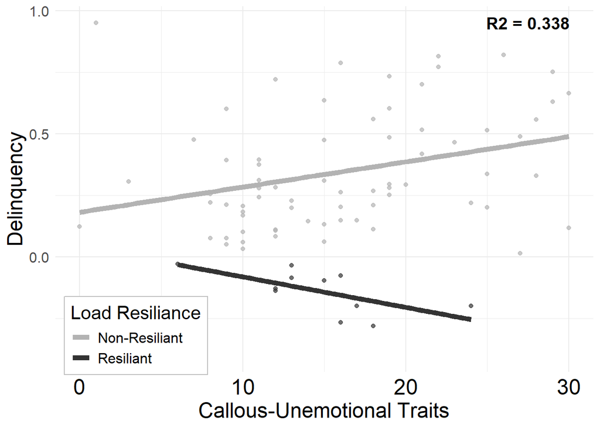

```r
delq.pred <- predict(delq_m)

ll <- rep(0, length(delq.pred))
ll[which(delq.pred<=0)] <- 1

ggplot(
  data=dat,
  aes(
    x=cu_total_sum,
    y=delq.pred,
    group = factor(ll),
    colour = factor(ll)
  )
) +
  geom_smooth(
    method='lm',
    se=FALSE,
    size=2
  ) +
  geom_point(alpha=0.7)+
  labs(
    x="Callous-Unemotional Traits",
    y="Delinquency"
  ) +
  scale_colour_grey(
    "Load Resiliance",
    start = .7,
    end= .2,
    labels = c("Non-Resiliant", "Resiliant")
  ) +
  theme_minimal() +       # setting theme and text parameters
  theme(
    axis.text=element_text(
      size=rel(1.1)
    ),
    axis.title=element_text(
      size=rel(1.6)
    ),
    strip.text.x.top = element_text(
      colour = "black",
      face = "bold",
      size=rel(2.5)
    ),
    axis.text.x = element_text(
      colour = "black",
      face="plain",
      size=rel(1.5)
    ),
    legend.title = element_text(
      size=rel(1.4)
    ),
    legend.text = element_text(
      size=rel(1.1)
    ),
    legend.position = c(0.15,0.1),
    legend.background = element_rect(
      fill="white",
      color = "grey")
  ) +
  ylim(-0.4,0.95) +
  annotate("text",
               x=27.5,
               y= 0.95,
               label = paste("R2", "=", round(performance(delq_m)$R2_marginal,3)),
               fontface="bold",
               size=5
               )
```

```r
ggsave(
  paste0(base_fig,"\\delinquency.tiff"),
  plot = last_plot(),
  device = "tiff",
  scale = 1,
  width = 5,
  height = 5,
  units = "in",
  dpi = 300
)
```

# 6 Tertiary Analyses

- Here we examine (1) baseline single ToM (2) odds ratio test > control
  - 1. we run a series of regression to examine phenotype associations with ToM
  - 2. we use a probability to determine if task caused effects

## 6.1 Single ToM

- Here we look at
  - **Accuracy** and **Reaction Time**
- NOTE - since this is a single performance - no need to look at test vs not
  - we only look at phenotype associations for the entire sample

### 6.1.1 Model

```r
models_s <- function(x) {
  model1 <- lm(x ~
                   cu_total_mean +
                   sdq_cd +
                   sex_male +
                   race_white +
                   iq +
                   careless +
                   sdq_hyperactivity +
                   sdq_internalizing,
                 data = dat)
  return(model1)
}


tom_s_df <- dat[,c(
  "tom_s_acc_total_sum",
  "tom_s_acc_at_sum",
  "tom_s_acc_ct_sum",
  "tom_s_acc_pc_sum",
  "tom_s_rt_total_mean",
  "tom_s_rt_at_mean",
  "tom_s_rt_ct_mean",
  "tom_s_rt_pc_mean"
  )
  ]
tom_s_out <- apply(tom_s_df,2, models_s)
```

### 6.1.2 Results

```r
ind <- 1
for (ii in tom_s_out){
  s_name <- names(tom_s_out[ind])
  ind <- ind+1
  s_out <- summary(ii)
  cat(c("\n \n", s_name," ~\n"))
  print(s_out)
  s_df<-as.data.frame(s_out$coefficients)
  write.csv(
    s_df,
    paste0(base,"\\single_", s_name, ".csv"),
    row.names = TRUE
  )
}
```

```
##
##
##  tom_s_acc_total_sum  ~
##
## Call:
## lm(formula = x ~ cu_total_mean + sdq_cd + sex_male + race_white +
##     iq + careless + sdq_hyperactivity + sdq_internalizing, data = dat)
##
## Residuals:
##      Min       1Q   Median       3Q      Max
## -13.2470  -1.9428   0.8907   3.0640  10.1778
##
## Coefficients:
##                   Estimate Std. Error t value Pr(>|t|)
## (Intercept)       11.67035    3.48584   3.348  0.00127 **
## cu_total_mean      1.84640    2.11324   0.874  0.38502
## sdq_cd            -1.04399    0.44373  -2.353  0.02122 *
## sex_male          -0.84386    1.18629  -0.711  0.47905
## race_white         1.52836    1.20065   1.273  0.20692
## iq                 0.06422    0.03304   1.944  0.05560 .
## careless          -2.43786    1.41622  -1.721  0.08925 .
## sdq_hyperactivity  0.43627    0.27644   1.578  0.11867
## sdq_internalizing  0.12727    0.19497   0.653  0.51587
## ---
## Signif. codes:  0 '***' 0.001 '**' 0.01 '*' 0.05 '.' 0.1 ' ' 1
##
## Residual standard error: 4.869 on 76 degrees of freedom
## Multiple R-squared:  0.1876, Adjusted R-squared:  0.1021
## F-statistic: 2.194 on 8 and 76 DF,  p-value: 0.03701
##
##
##
##  tom_s_acc_at_sum  ~
##
## Call:
## lm(formula = x ~ cu_total_mean + sdq_cd + sex_male + race_white +
##     iq + careless + sdq_hyperactivity + sdq_internalizing, data = dat)
##
## Residuals:
##     Min      1Q  Median      3Q     Max
```

[output cut: 184 more lines]

```
## (Intercept)        3.0586997  0.5408201   5.656  2.6e-07 ***
## cu_total_mean      0.1566636  0.3278647   0.478    0.634
## sdq_cd             0.0830924  0.0688432   1.207    0.231
## sex_male           0.0002708  0.1840503   0.001    0.999
## race_white        -0.2710600  0.1862783  -1.455    0.150
## iq                -0.0049398  0.0051256  -0.964    0.338
## careless          -0.2699247  0.2197233  -1.228    0.223
## sdq_hyperactivity -0.0491290  0.0428887  -1.146    0.256
## sdq_internalizing  0.0015993  0.0302489   0.053    0.958
## ---
## Signif. codes:  0 '***' 0.001 '**' 0.01 '*' 0.05 '.' 0.1 ' ' 1
##
## Residual standard error: 0.7554 on 76 degrees of freedom
## Multiple R-squared:  0.08228,    Adjusted R-squared:  -0.01432
## F-statistic: 0.8517 on 8 and 76 DF,  p-value: 0.5607
```

## 6.2 Odds Ratio of Test Exposure

```r
  # creating change score for overall ToM
diff_tom <- (
  (random.intercpet.preds_accuracy_total[86:170] -
    random.intercpet.preds_accuracy_total[0:85]) +
    abs(mean((random.intercpet.preds_accuracy_total[86:170] -
    random.intercpet.preds_accuracy_total[0:85])[which(dat$group_di==0)]))
)
  # creating a probability of reduction during dual task
    ## initiating list
p_n <- rep(0,length(diff_tom))
  ## Identifying those lower than 0 to indicate reduction in ToM performance
p_n[which(diff_tom < 0)] <- 1

  # calculating probabilities for OR
    ## probability of negative in test group
p_n_test <- mean(p_n ==1 &  dat$group_di ==1)
    ## probability of positive for test group
p_p_test <- mean(p_n ==0 &  dat$group_di ==1)
    ## probability of negative for control group
p_n_ctrl <- mean(p_n ==1 &  dat$group_di ==0)
    ## probability of positive for control group
p_p_ctrl <- mean(p_n ==0 &  dat$group_di ==0)

OR <- (p_n_test/p_p_test) / (p_n_ctrl/p_p_ctrl)


print(paste("Odds ratio of test > control group effect (no phenotype) negatively impacting ToM = ", OR))
```

```
## [1] "Odds ratio of test > control group effect (no phenotype) negatively impacting ToM =  3.75"
```